# Anime Recommendation System With Spark

**Group Members**

- 211805076 Mehmet ÖZCAN
- 211805036 Ahmet Muhammed AYDIN
- 211805008 Fedai PAÇA

# Configuration and Environment Constants

Use last 4 digits of the student number as seed value

```python
student_id = "211805008"

GLOBAL_SEED = int(student_id[-5:])
print(f"Global seed: {GLOBAL_SEED}")
```

```
Global seed: 5008
```

Print out some computer informations

```python
import platform
import psutil

system = platform.system()
release = platform.release()
version = platform.version()
machine = platform.machine()
processor = platform.processor()
operating_system = platform.platform()

print(f"System: {system}")
print(f"Release: {release}")
print(f"Version: {version}")
print(f"Machine: {machine}")
print(f"Processor: {processor}")
print(f"Operating System: {operating_system}")

cpu_cores = psutil.cpu_count()
memory = psutil.virtual_memory()
total_memory_gb = memory.total / (1024 * 1024 * 1024)  # Convert to GB

print(f"Total CPU cores: {cpu_cores}")
print(f"Total Memory: {total_memory_gb:.2f} GB")
```

```
System: Darwin
Release: 24.4.0
Version: Darwin Kernel Version 24.4.0: Wed Mar 19 21:18:03 PDT 2025; root:xnu-11417.101.15~1/RELEASE_ARM64_T8112
Machine: arm64
Processor: arm
Operating System: macOS-15.4-arm64-arm-64bit
Total CPU cores: 8
Total Memory: 16.00 GB
```

# Init Spark Session

```python
from pyspark.sql import SparkSession
import findspark


# if there is an existing Spark session, stop it to avoid conflicts
def stop_existing_spark():
    try:
        existing_spark = SparkSession.getActiveSession()
        if existing_spark:
            print("Stopping existing Spark session...")
            existing_spark.stop()
            print("Existing Spark session stopped.")
    except Exception as e:
        print(f"Error while stopping existing Spark session: {e}")


stop_existing_spark()


# Below line should be on top.
# to be able to find spark/pyspark installation and set up the SPARK_HOME environment variable
findspark.init()


print("Creating new Spark session...")

# Serialization converts objects into a format that can be stored or transmitted
# In Spark, when data moves between different processes or nodes, objects must be serialized
#
# In our anime recommendation context:
# - User ratings, anime features, and model parameters need to be serialized when:
#   1. Shuffling data across partitions during joins (users + animes + ratings)
#   3. Saving/loading trained recommendation models to/from disk
#   4. Caching DataFrames in memory across cluster nodes
#
# Kryo serializer makes these operations faster and uses less memory compared to Java's default serializer
# This is especially important for recommendation systems that process large datasets with millions of ratings
# So, we configure Spark to use Kryo serialization for better performance and efficiency

spark = (
    SparkSession.builder.appName("AnimeRecommender")  # Application name for identification in Spark UI
    .master("local[*]")  # Run locally using all available CPU cores
    .config("spark.driver.memory", "6g")  # Allocate 6GB RAM to the driver process
    .config("spark.sql.shuffle.partitions", "100")  # Set number of partitions for shuffle operations (default is 200)
    .config("spark.network.timeout", "800s")  # Network timeout to prevent connection failures during long operations
    .config("spark.executor.heartbeatInterval", "30s")  # Frequency of heartbeat signals from executors to driver
    .config("spark.driver.extraJavaOptions", "-Xss12m")  # Increase driver JVM stack size to 12MB (prevents stack overflow)
    .config("spark.executor.extraJavaOptions", "-Xss12m")  # Increase executor JVM stack size to 12MB
    .config("spark.serializer", "org.apache.spark.serializer.KryoSerializer")  # Use faster Kryo serialization instead of Java serialization
    .config("spark.kryoserializer.buffer.max", "1024m")  # Maximum buffer size for Kryo serializer (1GB)
    .config("spark.kryo.unsafe", "true")  # Enable unsafe operations in Kryo for better performance
    .config("spark.kryo.referenceTracking", "false")  # Disable reference tracking in Kryo to improve performance
    .config("spark.rdd.compress", "true")  # Compress RDD data to save memory at cost of CPU
    .config("spark.memory.fraction", "0.7")  # Use 70% of heap space for execution and storage (30% for other operations)
    .config("spark.cleaner.referenceTracking.cleanCheckpoints", "true")  # Automatically clean up checkpoint files
    .config("spark.cleaner.periodicGC.interval", "30s")  # Run garbage collection every 30 seconds to free up memory
    .getOrCreate()
)


spark.sparkContext.setCheckpointDir("/tmp/spark-checkpoints")

# log only errors to reduce verbosity
spark.sparkContext.setLogLevel("ERROR")

print("New Spark session created:", spark.version)
```

```
Creating new Spark session...
New Spark session created: 4.0.0
```

# Load data

Load users_animes data set which contains ratings (`user` scored the `anime` with `score`) of users for animes

```python
# for development purposes, you can uncomment the next line to sample a smaller dataset
# users_animes_df = spark.read.parquet("../data/users_animes.parquet").sample(0.01, seed=GLOBAL_SEED)
users_animes_df = spark.read.parquet("../data/users_animes.parquet")


print("users_animes_df count:", users_animes_df.count())

users_animes_df.printSchema()
```

```
[Stage 1:>                                                          (0 + 8) / 8]
```

```
users_animes_df count: 31284030
root
 |-- username: string (nullable = true)
 |-- anime_id: long (nullable = true)
 |-- my_score: long (nullable = true)
```

Load animes which holds animes informations

```python
animes_df = spark.read.parquet("../data/animes.parquet")

print("animes_df count:", animes_df.count())

animes_df.printSchema()
```

```
animes_df count: 6668
root
 |-- anime_id: long (nullable = true)
 |-- title: string (nullable = true)
 |-- title_english: string (nullable = true)
 |-- title_japanese: string (nullable = true)
 |-- title_synonyms: string (nullable = true)
 |-- image_url: string (nullable = true)
 |-- type: string (nullable = true)
 |-- source: string (nullable = true)
 |-- episodes: long (nullable = true)
 |-- status: string (nullable = true)
 |-- airing: boolean (nullable = true)
 |-- aired_string: string (nullable = true)
 |-- aired: string (nullable = true)
 |-- duration: string (nullable = true)
 |-- rating: string (nullable = true)
 |-- score: double (nullable = true)
 |-- scored_by: long (nullable = true)
 |-- rank: double (nullable = true)
 |-- popularity: long (nullable = true)
 |-- members: long (nullable = true)
 |-- favorites: long (nullable = true)
 |-- background: string (nullable = true)
 |-- premiered: string (nullable = true)
 |-- broadcast: string (nullable = true)
 |-- related: string (nullable = true)
 |-- producer: string (nullable = true)
 |-- licensor: string (nullable = true)
 |-- studio: string (nullable = true)
 |-- genre: string (nullable = true)
 |-- opening_theme: string (nullable = true)
 |-- ending_theme: string (nullable = true)
 |-- duration_min: double (nullable = true)
 |-- aired_from_year: double (nullable = true)
```

Load users data set which have users information

```python
users_df = spark.read.parquet("../data/users.parquet")

print("users_df count:", users_df.count())

users_df.printSchema()
```

```
users_df count: 108711
root
 |-- username: string (nullable = true)
 |-- user_id: long (nullable = true)
 |-- user_watching: long (nullable = true)
 |-- user_completed: long (nullable = true)
 |-- user_onhold: long (nullable = true)
 |-- user_dropped: long (nullable = true)
 |-- user_plantowatch: long (nullable = true)
 |-- user_days_spent_watching: double (nullable = true)
 |-- gender: string (nullable = true)
 |-- location: string (nullable = true)
 |-- birth_date: string (nullable = true)
 |-- access_rank: double (nullable = true)
 |-- join_date: string (nullable = true)
 |-- last_online: string (nullable = true)
 |-- stats_mean_score: double (nullable = true)
 |-- stats_rewatched: double (nullable = true)
 |-- stats_episodes: long (nullable = true)
```

# Prepare Data

we have

- users_df : has users info
- animes_df: has animes info
- users_animes_df: has scores info

```python
users_animes_first_10 = users_animes_df.limit(10).toPandas()
display(users_animes_first_10)

animes_first_10 = animes_df.limit(10).toPandas()
display(animes_first_10)

users_first_10 = users_df.limit(10).toPandas()
display(users_first_10)
```

|  | username | anime_id | my_score |
| --- | --- | --- | --- |
| 0 | karthiga | 21 | 9 |
| 1 | karthiga | 59 | 7 |
| 2 | karthiga | 74 | 7 |
| 3 | karthiga | 120 | 7 |
| 4 | karthiga | 178 | 7 |
| 5 | karthiga | 210 | 7 |
| 6 | karthiga | 232 | 6 |
| 7 | karthiga | 233 | 6 |
| 8 | karthiga | 249 | 8 |
| 9 | karthiga | 269 | 10 |

|  | anime_id | title | title_english | title_japanese | title_synonyms | image_url | type | source | episodes | status | ... | broadcast | related | producer | licensor | studio | genre | opening_theme | ending_theme | duration_min | aired_from_year |
| --- | --- | --- | --- | --- | --- | --- | --- | --- | --- | --- | --- | --- | --- | --- | --- | --- | --- | --- | --- | --- | --- |
| 0 | 11013 | Inu x Boku SS | Inu X Boku Secret Service | 妖狐×僕SS | Youko x Boku SS | https://myanimelist.cdn-dena.com/images/anime/... | TV | Manga | 12 | Finished Airing | ... | Fridays at Unknown | {'Adaptation': [{'mal_id': 17207, 'type': 'man... | Aniplex, Square Enix, Mainichi Broadcasting Sy... | Sentai Filmworks | David Production | Comedy, Supernatural, Romance, Shounen | ['"Nirvana" by MUCC'] | ['#1: "Nirvana" by MUCC (eps 1, 11-12)', '#2: ... | 24.0 | 2012.0 |
| 1 | 2104 | Seto no Hanayome | My Bride is a Mermaid | 瀬戸の花嫁 | The Inland Sea Bride | https://myanimelist.cdn-dena.com/images/anime/... | TV | Manga | 26 | Finished Airing | ... | Unknown | {'Adaptation': [{'mal_id': 759, 'type': 'manga... | TV Tokyo, AIC, Square Enix, Sotsu | Funimation | Gonzo | Comedy, Parody, Romance, School, Shounen | ['"Romantic summer" by SUN&LUNAR'] | ['#1: "Ashita e no Hikari (明日への光)" by Asuka Hi... | 24.0 | 2007.0 |
| 2 | 5262 | Shugo Chara!! Doki | Shugo Chara!! Doki | しゅごキャラ！！どきっ | Shugo Chara Ninenme, Shugo Chara! Second Year | https://myanimelist.cdn-dena.com/images/anime/... | TV | Manga | 51 | Finished Airing | ... | Unknown | {'Adaptation': [{'mal_id': 101, 'type': 'manga... | TV Tokyo, Sotsu | None | Satelight | Comedy, Magic, School, Shoujo | ['#1: "Minna no Tamago (みんなのたまご)" by Shugo Cha... | ['#1: "Rottara Rottara (ロッタラ ロッタラ)" by Buono! ... | 24.0 | 2008.0 |
| 3 | 721 | Princess Tutu | Princess Tutu | プリンセスチュチュ | None | https://myanimelist.cdn-dena.com/images/anime/... | TV | Original | 38 | Finished Airing | ... | Fridays at Unknown | {'Adaptation': [{'mal_id': 1581, 'type': 'mang... | Memory-Tech, GANSIS, Marvelous AQL | ADV Films | Hal Film Maker | Comedy, Drama, Magic, Romance, Fantasy | ['"Morning Grace" by Ritsuko Okazaki'] | ['"Watashi No Ai Wa Chiisaikeredo" by Ritsuko ... | 16.0 | 2002.0 |
| 4 | 12365 | Bakuman. 3rd Season | Bakuman. | バクマン。 | Bakuman Season 3 | https://myanimelist.cdn-dena.com/images/anime/... | TV | Manga | 25 | Finished Airing | ... | Unknown | {'Adaptation': [{'mal_id': 9711, 'type': 'mang... | NHK, Shueisha | None | J.C.Staff | Comedy, Drama, Romance, Shounen | ['#1: "Moshimo no Hanashi (もしもの話)" by nano.RIP... | ['#1: "Pride on Everyday" by Sphere (eps 1-13)... | 24.0 | 2012.0 |
| 5 | 6586 | Yume-iro Pâtissière | None | 夢色パティシエール | Yumeiro Patissiere, YumePati, Dream-Colored Pa... | https://myanimelist.cdn-dena.com/images/anime/... | TV | Manga | 50 | Finished Airing | ... | Unknown | {'Adaptation': [{'mal_id': 10386, 'type': 'man... | Yomiuri Telecasting, DAX Production, Shueisha | None | Studio Pierrot, Studio Hibari | Kids, School, Shoujo | ['"Yume ni Yell! Patissiere♪ (夢にエール！パティシエール♪)"... | ['"Ichigo no Miracle (いちごのミラクルール)" by Yukina S... | 24.0 | 2009.0 |
| 6 | 178 | Ultra Maniac | Ultramaniac - Magical Girl | ウルトラマニアック | None | https://myanimelist.cdn-dena.com/images/anime/... | TV | Manga | 26 | Finished Airing | ... | Tuesdays at 22:00 (JST) | {'Adaptation': [{'mal_id': 956, 'type': 'manga... | WAO World, Studio Jack | Discotek Media, Geneon Entertainment USA | Production Reed | Magic, Comedy, Romance, School, Shoujo | ['"Kagami no Naka" by can/goo'] | ['"Hitotsu=Unmei Kyoudoutai" by can/goo'] | 24.0 | 2003.0 |
| 7 | 2787 | Shakugan no Shana II (Second) | Shakugan no Shana: Season II | 灼眼のシャナII –Second– | Shakugan no Shana 2 | https://myanimelist.cdn-dena.com/images/anime/... | TV | Light novel | 24 | Finished Airing | ... | Fridays at 01:25 (JST) | {'Adaptation': [{'mal_id': 3074, 'type': 'mang... | Geneon Universal Entertainment, ASCII Media Works | Funimation | J.C.Staff | Action, Drama, Fantasy, Romance, School, Super... | ['#1: "JOINT" by Mami Kawada (eps 1-15)', '#2:... | ['#1: "Triangle" by Kawada Mami (eps 1-15)', '... | 24.0 | 2007.0 |
| 8 | 4477 | Nodame Cantabile: Paris-hen | None | のだめカンタービレ 巴里編 | Nodame Cantabile Paris Chapter, Nodame Cantabi... | https://myanimelist.cdn-dena.com/images/anime/... | TV | Manga | 11 | Finished Airing | ... | Fridays at 00:45 (JST) | {'Adaptation': [{'mal_id': 419, 'type': 'manga... | Fuji TV, Asmik Ace Entertainment, Sony Music E... | None | J.C.Staff | Music, Slice of Life, Comedy, Romance, Josei | ['"Sky High!" by The Gospellers'] | ['"東京 et 巴里 (Tokyo and Paris)" by Emiri Miyamo... | 23.0 | 2008.0 |
| 9 | 853 | Ouran Koukou Host Club | Ouran High School Host Club | 桜蘭高校ホスト部 | Ohran Koko Host Club, Ouran Koukou Hosutobu, O... | https://myanimelist.cdn-dena.com/images/anime/... | TV | Manga | 26 | Finished Airing | ... | Wednesdays at 00:50 (JST) | {'Adaptation': [{'mal_id': 30, 'type': 'manga'... | VAP, Hakusensha, Nippon Television Network | Funimation | Bones | Comedy, Harem, Romance, School, Shoujo | ['"Sakura Kiss" by Chieko Kawabe'] | ['"Shissou" by Last Alliance'] | 23.0 | 2006.0 |

10 rows × 33 columns

|  | username | user_id | user_watching | user_completed | user_onhold | user_dropped | user_plantowatch | user_days_spent_watching | gender | location | birth_date | access_rank | join_date | last_online | stats_mean_score | stats_rewatched | stats_episodes |
| --- | --- | --- | --- | --- | --- | --- | --- | --- | --- | --- | --- | --- | --- | --- | --- | --- | --- |
| 0 | karthiga | 2255153 | 3 | 49 | 1 | 0 | 0 | 55.091667 | Female | Chennai, India | 1990-04-29 00:00:00 | NaN | 2013-03-03 00:00:00 | 2014-02-04 01:32:00 | 7.43 | 0.0 | 3391 |
| 1 | Damonashu | 37326 | 45 | 195 | 27 | 25 | 59 | 82.574306 | Male | Detroit,Michigan | 1991-08-01 00:00:00 | NaN | 2008-02-13 00:00:00 | 2017-07-10 06:52:54 | 6.15 | 6.0 | 4903 |
| 2 | bskai | 228342 | 25 | 414 | 2 | 5 | 11 | 159.483333 | Male | Nayarit, Mexico | 1990-12-14 00:00:00 | NaN | 2009-08-31 00:00:00 | 2014-05-12 16:35:00 | 8.27 | 1.0 | 9701 |
| 3 | terune_uzumaki | 327311 | 5 | 5 | 0 | 0 | 0 | 11.394444 | Female | Malaysia, Kuantan | 1998-08-24 00:00:00 | NaN | 2010-05-10 00:00:00 | 2012-10-18 19:06:00 | 9.70 | 6.0 | 697 |
| 4 | Bas_G | 5015094 | 35 | 114 | 6 | 20 | 175 | 30.458333 | Male | Nijmegen, Nederland | 1999-10-24 00:00:00 | NaN | 2015-11-26 00:00:00 | 2018-05-10 20:53:37 | 7.86 | 0.0 | 1847 |
| 5 | HimeAria | 3129315 | 2 | 87 | 2 | 0 | 28 | 19.963194 | Female | Poland | 1996-09-26 00:00:00 | NaN | 2013-09-08 00:00:00 | 2018-01-14 13:05:42 | 8.23 | 0.0 | 1314 |
| 6 | Skallington | 326733 | 0 | 3 | 0 | 0 | 0 | 1.234722 | Male | Norberg Sweden | 1991-03-15 00:00:00 | NaN | 2010-05-09 00:00:00 | 2010-05-12 06:29:00 | 10.00 | 7.0 | 73 |
| 7 | Slimak | 61677 | 79 | 224 | 0 | 3 | 84 | 124.731944 | Male | Poland | 1988-02-21 00:00:00 | NaN | 2008-05-18 00:00:00 | 2018-05-01 12:05:21 | 7.77 | 2.0 | 7447 |
| 8 | Elysiun | 5927342 | 7 | 4 | 0 | 0 | 4 | 2.057639 | Male | Nebraska | 1984-11-16 00:00:00 | NaN | 2016-12-25 00:00:00 | 2017-03-11 21:37:00 | 7.40 | 0.0 | 121 |
| 9 | jimothy000 | 47167 | 6 | 0 | 0 | 0 | 2 | 2.040972 | Male | England,Manchester | 1995-04-25 00:00:00 | NaN | 2008-04-01 00:00:00 | 2008-04-27 16:00:00 | 9.33 | 5.0 | 126 |

Select required columns (subset of dataframes) to work with. With that being said, users_animes_df is already has proper columns so lets keep it as it is.

```python
print("count of users_animes_df:", users_animes_df.count())

# username, anime_id and my_score is crucial for the recommender system
# we can safely drop the rows with null values in these columns
cleaned_users_animes_df = users_animes_df.select("*").dropna()

cleaned_users_animes_df.show()
print("cleaned_users_animes_df count:", cleaned_users_animes_df.count())
```

```
count of users_animes_df: 31284030
+--------+--------+--------+
|username|anime_id|my_score|
+--------+--------+--------+
|karthiga|      21|       9|
|karthiga|      59|       7|
|karthiga|      74|       7|
|karthiga|     120|       7|
|karthiga|     178|       7|
|karthiga|     210|       7|
|karthiga|     232|       6|
|karthiga|     233|       6|
|karthiga|     249|       8|
|karthiga|     269|      10|
|karthiga|     721|       7|
|karthiga|     853|       7|
|karthiga|     857|      10|
|karthiga|     957|       8|
|karthiga|     966|      10|
|karthiga|    1557|       8|
|karthiga|    1571|       8|
|karthiga|    1579|       9|
|karthiga|    1698|       7|
|karthiga|    1735|       9|
+--------+--------+--------+
only showing top 20 rows
cleaned_users_animes_df count: 31283787
```

```python
# Drop rows with any missing (null) values in the selected columns
cleaned_animes_df = animes_df.select(
    "anime_id", "title", "episodes", "rating", "score", "scored_by", "rank", "popularity", "members", "favorites", "studio"
).dropna()
```

```python
cleaned_users_df = users_df.select("user_id", "username", "user_completed", "gender", "birth_date").dropna()
```

Since MyAnimeList is an online community web site, it would be very naive to trust datas. The datas are not being tracked by an autamed system but added by hand by users. So lets make some clean ups at least to have some realistic data. Look like the popular ones are matching. So lets make the recommendation service more like `popular anime oriented` base.

```python
cleaned_animes_df.show()
cleaned_animes_df.count()
```

```
+--------+--------------------+--------+--------------------+-----+---------+------+----------+-------+---------+--------------------+
|anime_id|               title|episodes|              rating|score|scored_by|  rank|popularity|members|favorites|              studio|
+--------+--------------------+--------+--------------------+-----+---------+------+----------+-------+---------+--------------------+
|   11013|       Inu x Boku SS|      12|PG-13 - Teens 13 ...| 7.63|   139250|1274.0|       231| 283882|     2809|    David Production|
|    2104|    Seto no Hanayome|      26|PG-13 - Teens 13 ...| 7.89|    91206| 727.0|       366| 204003|     2579|               Gonzo|
|    5262|  Shugo Chara!! Doki|      51|       PG - Children| 7.55|    37129|1508.0|      1173|  70127|      802|           Satelight|
|     721|       Princess Tutu|      38|PG-13 - Teens 13 ...| 8.21|    36501| 307.0|       916|  93312|     3344|      Hal Film Maker|
|   12365| Bakuman. 3rd Season|      25|PG-13 - Teens 13 ...| 8.67|   107767|  50.0|       426| 182765|     2082|           J.C.Staff|
|    6586| Yume-iro Pâtissière|      50|        G - All Ages| 8.03|    21618| 526.0|      1630|  45625|      826|Studio Pierrot, S...|
|     178|        Ultra Maniac|      26|        G - All Ages| 7.26|     9663|2594.0|      2490|  22778|      122|     Production Reed|
|    2787|Shakugan no Shana...|      24|PG-13 - Teens 13 ...| 7.72|   126085|1066.0|       332| 220591|     1075|           J.C.Staff|
|    4477|Nodame Cantabile:...|      11|PG-13 - Teens 13 ...| 8.24|    53908| 281.0|       988|  85660|      282|           J.C.Staff|
|     853|Ouran Koukou Host...|      26|PG-13 - Teens 13 ...| 8.34|   335137| 205.0|        69| 538843|    24072|               Bones|
|    4814|  Junjou Romantica 2|      12|PG-13 - Teens 13 ...| 8.15|    66565| 374.0|       799| 108186|     1123|         Studio Deen|
|    7054|Kaichou wa Maid-s...|      26|PG-13 - Teens 13 ...|  8.2|   315130| 314.0|        71| 531292|    14436|           J.C.Staff|
|   11123|Sekaiichi Hatsukoi 2|      12|PG-13 - Teens 13 ...| 8.23|    53285| 288.0|       945|  89543|      726|         Studio Deen|
|   14227|Tonari no Kaibuts...|      13|PG-13 - Teens 13 ...| 7.71|   281448|1093.0|        88| 482105|     4064|   Brain&#039;s Base|
|     269|              Bleach|     366|PG-13 - Teens 13 ...|  7.9|   433097| 693.0|        18| 819284|    40718|      Studio Pierrot|
|      59|             Chobits|      26|PG-13 - Teens 13 ...| 7.53|   175388|1546.0|       188| 317641|     3271|            Madhouse|
|    6045|      Kimi ni Todoke|      25|PG-13 - Teens 13 ...| 8.13|   212710| 400.0|       111| 417136|     8041|      Production I.G|
|    1735|  Naruto: Shippuuden|     500|PG-13 - Teens 13 ...| 8.18|   385179| 337.0|        20| 794112|    42846|      Studio Pierrot|
|     210|             Ranma ½|     161|    R+ - Mild Nudity| 7.85|    59911| 802.0|       623| 134537|     2742|         Studio Deen|
|    4224|           Toradora!|      25|PG-13 - Teens 13 ...| 8.39|   557898| 174.0|        13| 910373|    35322|           J.C.Staff|
+--------+--------------------+--------+--------------------+-----+---------+------+----------+-------+---------+--------------------+
only showing top 20 rows
```

```
6230
```

### Cleaning Dataset

We made some initial clean up in myanimelist dataset by removing the rows that has null values. Lets continue to further clean up process.

Lets work with animes which have more than 1 episodes.

```python
# To be realistic we will only keep animes with more than 1 episode
cleaned_animes_df = cleaned_animes_df.filter(cleaned_animes_df.episodes > 1)

cleaned_animes_df.count()
```

```
4030
```

We have almost 2000 animes less than 1 episodes. Some of them might be movies which have only 1 episodes. But for simplicity, lets continue with that.

Lets see the distribution of animes based on their member counts.

### Using RDD and map to see members distribution

```python
# Get members as RDD
member_counts_rdd = cleaned_animes_df.select("members").rdd.map(lambda row: int(row.members))

min_members = member_counts_rdd.min()
max_members = member_counts_rdd.max()
print(f"Minimum members: {min_members}")
print(f"Maximum members: {max_members}")

num_buckets = 10
bucket_size = (max_members - min_members) / num_buckets
print(f"Bucket size: {bucket_size}")
```

```
Minimum members: 37
Maximum members: 1456378
Bucket size: 145634.1
```

```python
def get_bucket_index(members, min_val, bucket_size, num_buckets):
    if members == min_val:
        return 0
    index = int((members - min_val) // bucket_size)
    # Ensure the last bucket includes the maximum value
    return min(index, num_buckets - 1)

bucketed_rdd = member_counts_rdd.map(lambda members: (get_bucket_index(members, min_members, bucket_size, num_buckets), 1))

bucket_counts_rdd = bucketed_rdd.reduceByKey(lambda a, b: a + b)
bucket_counts = bucket_counts_rdd.sortByKey().collect()

print("Bucket Counts:")
for bucket_index, count in bucket_counts:
    print(f"Bucket {bucket_index}: {count} animes")
```

```
Bucket Counts:
Bucket 0: 3520 animes
Bucket 1: 303 animes
Bucket 2: 112 animes
Bucket 3: 41 animes
Bucket 4: 22 animes
Bucket 5: 19 animes
Bucket 6: 8 animes
Bucket 7: 1 animes
Bucket 8: 2 animes
Bucket 9: 2 animes
```

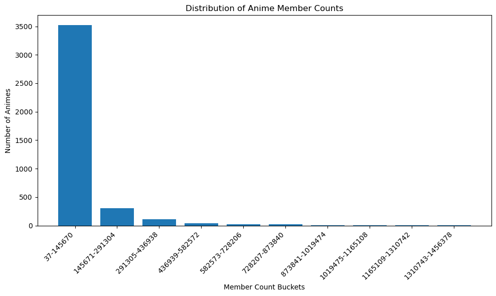

```python
import matplotlib.pyplot as plt

bucket_indices = [item[0] for item in bucket_counts]
counts = [item[1] for item in bucket_counts]

bucket_ranges = []
for i in range(num_buckets):
    start = int(min_members + i * bucket_size)
    end = int(min_members + (i + 1) * bucket_size) - 1
    if i == num_buckets - 1:
        end = max_members
    bucket_ranges.append(f"{start}-{end}")

plt.figure(figsize=(10, 6))
plt.bar(bucket_indices, counts, tick_label=bucket_ranges)
plt.xlabel("Member Count Buckets")
plt.ylabel("Number of Animes")
plt.title("Distribution of Anime Member Counts")
plt.xticks(rotation=45, ha="right")
plt.tight_layout()
plt.show()
```

Seems like a few hundered animes has more than 100k members. And just a few of them have over million members. Lets focus the ones less than 145670. Maybe we have just with a few members. And we can ignore them since we are going to recommend popular animes. Because of reduced row count, that way will also help us our life easier during training.

### Using map reduceByKey functions to see distribution of animes less than 145670 members

```
Minimum members (filtered): 37
Maximum members (filtered): 145539
Filtered bucket size: 7275.1

Filtered Bucket Counts:
Bucket 0: 1410 animes
Bucket 1: 485 animes
Bucket 2: 315 animes
Bucket 3: 221 animes
Bucket 4: 147 animes
Bucket 5: 133 animes
Bucket 6: 100 animes
Bucket 7: 103 animes
Bucket 8: 81 animes
Bucket 9: 81 animes
Bucket 10: 71 animes
Bucket 11: 55 animes
Bucket 12: 51 animes
Bucket 13: 43 animes
Bucket 14: 54 animes
Bucket 15: 36 animes
Bucket 16: 47 animes
Bucket 17: 34 animes
Bucket 18: 30 animes
Bucket 19: 23 animes
```

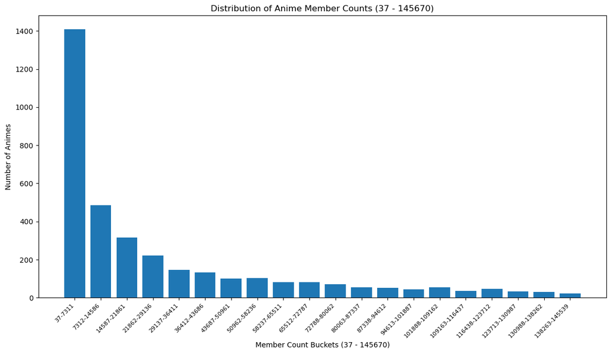

```python
filtered_member_counts_rdd = member_counts_rdd.filter(lambda members: 37 <= members <= 145670)

min_filtered_members = filtered_member_counts_rdd.min()
max_filtered_members = filtered_member_counts_rdd.max()
num_filtered_buckets = 20
filtered_bucket_size = (max_filtered_members - min_filtered_members) / num_filtered_buckets

print(f"Minimum members (filtered): {min_filtered_members}")
print(f"Maximum members (filtered): {max_filtered_members}")
print(f"Filtered bucket size: {filtered_bucket_size}")


def get_filtered_bucket_index(members, min_val, bucket_size, num_buckets):
    if members == min_val:
        return 0
    index = int((members - min_val) // bucket_size)
    return min(index, num_buckets - 1)


filtered_bucketed_rdd = filtered_member_counts_rdd.map(
    lambda members: (
        get_filtered_bucket_index(members, min_filtered_members, filtered_bucket_size, num_filtered_buckets),
        1,
    )
)

filtered_bucket_counts_rdd = filtered_bucketed_rdd.reduceByKey(lambda a, b: a + b)
filtered_bucket_counts = filtered_bucket_counts_rdd.sortByKey().collect()

print("\nFiltered Bucket Counts:")
for bucket_index, count in filtered_bucket_counts:
    print(f"Bucket {bucket_index}: {count} animes")


filtered_bucket_indices = [item[0] for item in filtered_bucket_counts]
filtered_counts = [item[1] for item in filtered_bucket_counts]

filtered_bucket_ranges = []
for i in range(num_filtered_buckets):
    start = int(min_filtered_members + i * filtered_bucket_size)
    end = int(min_filtered_members + (i + 1) * filtered_bucket_size) - 1
    if i == num_filtered_buckets - 1:
        end = max_filtered_members
    filtered_bucket_ranges.append(f"{start}-{end}")

plt.figure(figsize=(12, 7))
plt.bar(filtered_bucket_indices, filtered_counts, tick_label=filtered_bucket_ranges)
plt.xlabel("Member Count Buckets (37 - 145670)")
plt.ylabel("Number of Animes")
plt.title("Distribution of Anime Member Counts (37 - 145670)")
plt.xticks(rotation=45, ha="right", fontsize=8)
plt.tight_layout()
plt.show()
```

```python
cleaned_animes_df.count()
```

```
4030
```

```python
from pyspark.sql.functions import col

cleaned_animes_df = cleaned_animes_df.filter(col("members") > 5000)
```

```python
cleaned_animes_df.show()

print("cleaned_animes_df count:", cleaned_animes_df.count())
```

```
+--------+--------------------+--------+--------------------+-----+---------+------+----------+-------+---------+--------------------+
|anime_id|               title|episodes|              rating|score|scored_by|  rank|popularity|members|favorites|              studio|
+--------+--------------------+--------+--------------------+-----+---------+------+----------+-------+---------+--------------------+
|   11013|       Inu x Boku SS|      12|PG-13 - Teens 13 ...| 7.63|   139250|1274.0|       231| 283882|     2809|    David Production|
|    2104|    Seto no Hanayome|      26|PG-13 - Teens 13 ...| 7.89|    91206| 727.0|       366| 204003|     2579|               Gonzo|
|    5262|  Shugo Chara!! Doki|      51|       PG - Children| 7.55|    37129|1508.0|      1173|  70127|      802|           Satelight|
|     721|       Princess Tutu|      38|PG-13 - Teens 13 ...| 8.21|    36501| 307.0|       916|  93312|     3344|      Hal Film Maker|
|   12365| Bakuman. 3rd Season|      25|PG-13 - Teens 13 ...| 8.67|   107767|  50.0|       426| 182765|     2082|           J.C.Staff|
|    6586| Yume-iro Pâtissière|      50|        G - All Ages| 8.03|    21618| 526.0|      1630|  45625|      826|Studio Pierrot, S...|
|     178|        Ultra Maniac|      26|        G - All Ages| 7.26|     9663|2594.0|      2490|  22778|      122|     Production Reed|
|    2787|Shakugan no Shana...|      24|PG-13 - Teens 13 ...| 7.72|   126085|1066.0|       332| 220591|     1075|           J.C.Staff|
|    4477|Nodame Cantabile:...|      11|PG-13 - Teens 13 ...| 8.24|    53908| 281.0|       988|  85660|      282|           J.C.Staff|
|     853|Ouran Koukou Host...|      26|PG-13 - Teens 13 ...| 8.34|   335137| 205.0|        69| 538843|    24072|               Bones|
|    4814|  Junjou Romantica 2|      12|PG-13 - Teens 13 ...| 8.15|    66565| 374.0|       799| 108186|     1123|         Studio Deen|
|    7054|Kaichou wa Maid-s...|      26|PG-13 - Teens 13 ...|  8.2|   315130| 314.0|        71| 531292|    14436|           J.C.Staff|
|   11123|Sekaiichi Hatsukoi 2|      12|PG-13 - Teens 13 ...| 8.23|    53285| 288.0|       945|  89543|      726|         Studio Deen|
|   14227|Tonari no Kaibuts...|      13|PG-13 - Teens 13 ...| 7.71|   281448|1093.0|        88| 482105|     4064|   Brain&#039;s Base|
|     269|              Bleach|     366|PG-13 - Teens 13 ...|  7.9|   433097| 693.0|        18| 819284|    40718|      Studio Pierrot|
|      59|             Chobits|      26|PG-13 - Teens 13 ...| 7.53|   175388|1546.0|       188| 317641|     3271|            Madhouse|
|    6045|      Kimi ni Todoke|      25|PG-13 - Teens 13 ...| 8.13|   212710| 400.0|       111| 417136|     8041|      Production I.G|
|    1735|  Naruto: Shippuuden|     500|PG-13 - Teens 13 ...| 8.18|   385179| 337.0|        20| 794112|    42846|      Studio Pierrot|
|     210|             Ranma ½|     161|    R+ - Mild Nudity| 7.85|    59911| 802.0|       623| 134537|     2742|         Studio Deen|
|    4224|           Toradora!|      25|PG-13 - Teens 13 ...| 8.39|   557898| 174.0|        13| 910373|    35322|           J.C.Staff|
+--------+--------------------+--------+--------------------+-----+---------+------+----------+-------+---------+--------------------+
only showing top 20 rows
cleaned_animes_df count: 2841
```

```python
# do we have any animes scored between 0 and 1
cleaned_animes_df.filter(col("score") < 1).count()
```

```
0
```

### Using flatMap to see Score Distribution

Lets observe distribution of anime scores.

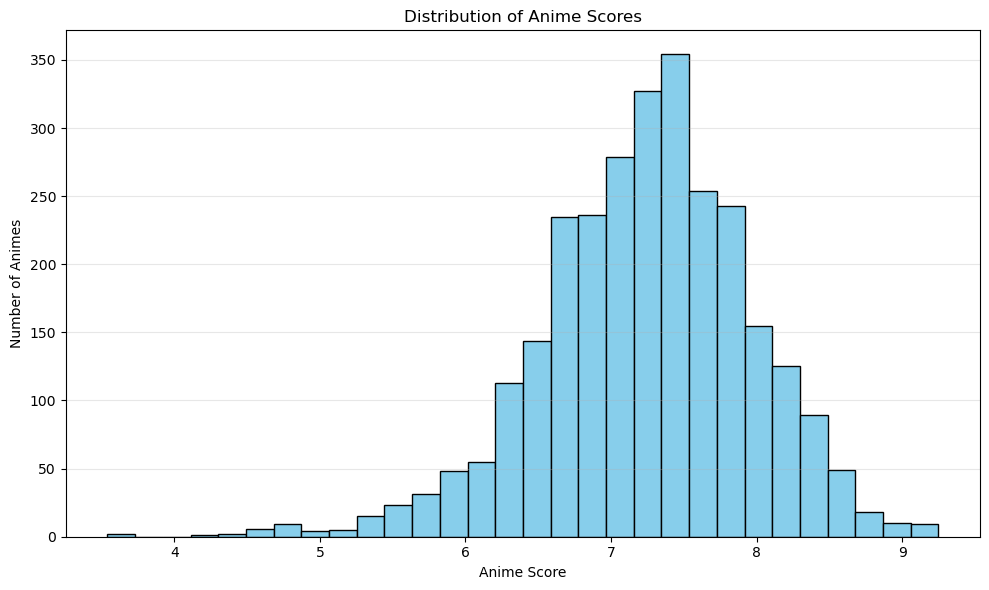

```python
# lets use rdd to collect the scores and plot the distribution
scores = cleaned_animes_df.select("score").rdd.flatMap(lambda x: [x[0]]).filter(lambda x: x is not None).collect()

plt.figure(figsize=(10, 6))
plt.hist(scores, bins=30, color='skyblue', edgecolor='black')
plt.xlabel("Anime Score")
plt.ylabel("Number of Animes")
plt.title("Distribution of Anime Scores")
plt.grid(axis='y', alpha=0.3)
plt.tight_layout()
plt.show()
```

We have some outliers at lower scores. Especially less than 6. Again since we are going to recommend popular animes, lets check if there are some animes have lower rates that we can ignore.

```python
cleaned_animes_df = cleaned_animes_df.filter(col("score") >= 6)
```

```python
cleaned_animes_df.show()
print("cleaned_animes_df count:", cleaned_animes_df.count())
```

```
+--------+--------------------+--------+--------------------+-----+---------+------+----------+-------+---------+--------------------+
|anime_id|               title|episodes|              rating|score|scored_by|  rank|popularity|members|favorites|              studio|
+--------+--------------------+--------+--------------------+-----+---------+------+----------+-------+---------+--------------------+
|   11013|       Inu x Boku SS|      12|PG-13 - Teens 13 ...| 7.63|   139250|1274.0|       231| 283882|     2809|    David Production|
|    2104|    Seto no Hanayome|      26|PG-13 - Teens 13 ...| 7.89|    91206| 727.0|       366| 204003|     2579|               Gonzo|
|    5262|  Shugo Chara!! Doki|      51|       PG - Children| 7.55|    37129|1508.0|      1173|  70127|      802|           Satelight|
|     721|       Princess Tutu|      38|PG-13 - Teens 13 ...| 8.21|    36501| 307.0|       916|  93312|     3344|      Hal Film Maker|
|   12365| Bakuman. 3rd Season|      25|PG-13 - Teens 13 ...| 8.67|   107767|  50.0|       426| 182765|     2082|           J.C.Staff|
|    6586| Yume-iro Pâtissière|      50|        G - All Ages| 8.03|    21618| 526.0|      1630|  45625|      826|Studio Pierrot, S...|
|     178|        Ultra Maniac|      26|        G - All Ages| 7.26|     9663|2594.0|      2490|  22778|      122|     Production Reed|
|    2787|Shakugan no Shana...|      24|PG-13 - Teens 13 ...| 7.72|   126085|1066.0|       332| 220591|     1075|           J.C.Staff|
|    4477|Nodame Cantabile:...|      11|PG-13 - Teens 13 ...| 8.24|    53908| 281.0|       988|  85660|      282|           J.C.Staff|
|     853|Ouran Koukou Host...|      26|PG-13 - Teens 13 ...| 8.34|   335137| 205.0|        69| 538843|    24072|               Bones|
|    4814|  Junjou Romantica 2|      12|PG-13 - Teens 13 ...| 8.15|    66565| 374.0|       799| 108186|     1123|         Studio Deen|
|    7054|Kaichou wa Maid-s...|      26|PG-13 - Teens 13 ...|  8.2|   315130| 314.0|        71| 531292|    14436|           J.C.Staff|
|   11123|Sekaiichi Hatsukoi 2|      12|PG-13 - Teens 13 ...| 8.23|    53285| 288.0|       945|  89543|      726|         Studio Deen|
|   14227|Tonari no Kaibuts...|      13|PG-13 - Teens 13 ...| 7.71|   281448|1093.0|        88| 482105|     4064|   Brain&#039;s Base|
|     269|              Bleach|     366|PG-13 - Teens 13 ...|  7.9|   433097| 693.0|        18| 819284|    40718|      Studio Pierrot|
|      59|             Chobits|      26|PG-13 - Teens 13 ...| 7.53|   175388|1546.0|       188| 317641|     3271|            Madhouse|
|    6045|      Kimi ni Todoke|      25|PG-13 - Teens 13 ...| 8.13|   212710| 400.0|       111| 417136|     8041|      Production I.G|
|    1735|  Naruto: Shippuuden|     500|PG-13 - Teens 13 ...| 8.18|   385179| 337.0|        20| 794112|    42846|      Studio Pierrot|
|     210|             Ranma ½|     161|    R+ - Mild Nudity| 7.85|    59911| 802.0|       623| 134537|     2742|         Studio Deen|
|    4224|           Toradora!|      25|PG-13 - Teens 13 ...| 8.39|   557898| 174.0|        13| 910373|    35322|           J.C.Staff|
+--------+--------------------+--------+--------------------+-----+---------+------+----------+-------+---------+--------------------+
only showing top 20 rows
cleaned_animes_df count: 2701
```

### Distrubtion of animes by count of voters

```python
from pyspark.sql import functions as F
import matplotlib.pyplot as plt

min_score = cleaned_animes_df.select(F.min("scored_by")).first()[0]
max_score = cleaned_animes_df.select(F.max("scored_by")).first()[0]
num_buckets = 10
bucket_size = (max_score - min_score) / num_buckets

bucketed_scored_by_df = cleaned_animes_df.withColumn(
    "bucket", F.floor((F.col("scored_by") - min_score) / bucket_size).cast("int")
)

# Count the number of animes in each bucket and collect all buckets
bucket_counts_scored_by_df = (
    bucketed_scored_by_df.groupBy("bucket")
    .agg(
        F.count("*").alias("count"),
        F.min("scored_by").alias("min_scored_by"),
        F.max("scored_by").alias("max_scored_by"),
    )
    .orderBy("bucket")
)

bucket_counts_scored_by = bucket_counts_scored_by_df.collect()

print("\nScored_by Bucket Counts:")
for row in bucket_counts_scored_by:
    print(
        f"Bucket {row['bucket']}: {row['count']} animes (Range: {int(row['min_scored_by'])}-{int(row['max_scored_by'])})"
    )
```

```
Scored_by Bucket Counts:
Bucket 0: 2363 animes (Range: 123-100916)
Bucket 1: 208 animes (Range: 101450-201622)
Bucket 2: 63 animes (Range: 202063-298034)
Bucket 3: 33 animes (Range: 304612-403377)
Bucket 4: 17 animes (Range: 410107-502213)
Bucket 5: 7 animes (Range: 514656-592994)
Bucket 6: 6 animes (Range: 623227-691845)
Bucket 7: 1 animes (Range: 733592-733592)
Bucket 9: 2 animes (Range: 915986-940211)
Bucket 10: 1 animes (Range: 1009477-1009477)
```

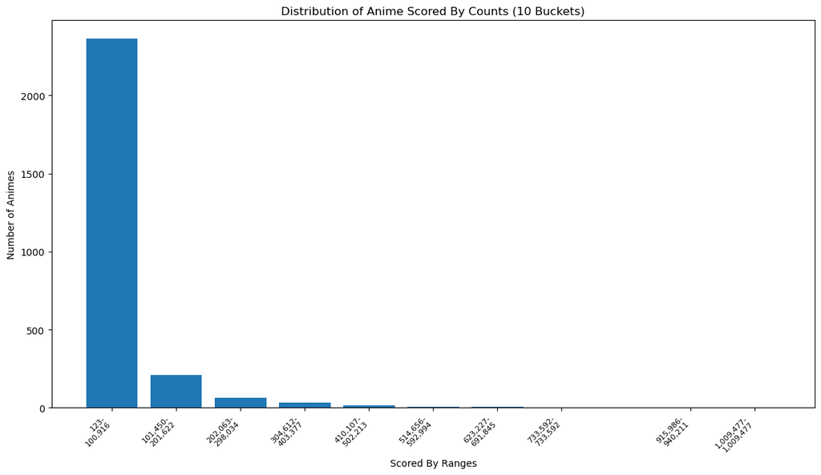

```python
bucket_indices_scored_by = [row['bucket'] for row in bucket_counts_scored_by]
counts_scored_by = [row['count'] for row in bucket_counts_scored_by]

bucket_ranges_scored_by = []
for row in bucket_counts_scored_by:
    start = int(row['min_scored_by'])
    end = int(row['max_scored_by'])
    bucket_ranges_scored_by.append(f"{start:,}-\n{end:,}")

plt.figure(figsize=(12, 7))
plt.bar(bucket_indices_scored_by, counts_scored_by, tick_label=bucket_ranges_scored_by)
plt.xlabel("Scored By Ranges")
plt.ylabel("Number of Animes")
plt.title(f"Distribution of Anime Scored By Counts ({len(bucket_indices_scored_by)} Buckets)")
plt.xticks(rotation=45, ha="right", fontsize=8)
plt.tight_layout()
plt.show()
```

```python
# how many animes we have scored_by less than 1000
cleaned_animes_df.filter(col("scored_by") < 1000).count()
```

```
14
```

```python
# lets remove animes with less than scored_by 1000
cleaned_animes_df = cleaned_animes_df.filter(col("scored_by") >= 1000)

cleaned_animes_df.show()
print("cleaned_animes_df count:", cleaned_animes_df.count())
```

```
+--------+--------------------+--------+--------------------+-----+---------+------+----------+-------+---------+--------------------+
|anime_id|               title|episodes|              rating|score|scored_by|  rank|popularity|members|favorites|              studio|
+--------+--------------------+--------+--------------------+-----+---------+------+----------+-------+---------+--------------------+
|   11013|       Inu x Boku SS|      12|PG-13 - Teens 13 ...| 7.63|   139250|1274.0|       231| 283882|     2809|    David Production|
|    2104|    Seto no Hanayome|      26|PG-13 - Teens 13 ...| 7.89|    91206| 727.0|       366| 204003|     2579|               Gonzo|
|    5262|  Shugo Chara!! Doki|      51|       PG - Children| 7.55|    37129|1508.0|      1173|  70127|      802|           Satelight|
|     721|       Princess Tutu|      38|PG-13 - Teens 13 ...| 8.21|    36501| 307.0|       916|  93312|     3344|      Hal Film Maker|
|   12365| Bakuman. 3rd Season|      25|PG-13 - Teens 13 ...| 8.67|   107767|  50.0|       426| 182765|     2082|           J.C.Staff|
|    6586| Yume-iro Pâtissière|      50|        G - All Ages| 8.03|    21618| 526.0|      1630|  45625|      826|Studio Pierrot, S...|
|     178|        Ultra Maniac|      26|        G - All Ages| 7.26|     9663|2594.0|      2490|  22778|      122|     Production Reed|
|    2787|Shakugan no Shana...|      24|PG-13 - Teens 13 ...| 7.72|   126085|1066.0|       332| 220591|     1075|           J.C.Staff|
|    4477|Nodame Cantabile:...|      11|PG-13 - Teens 13 ...| 8.24|    53908| 281.0|       988|  85660|      282|           J.C.Staff|
|     853|Ouran Koukou Host...|      26|PG-13 - Teens 13 ...| 8.34|   335137| 205.0|        69| 538843|    24072|               Bones|
|    4814|  Junjou Romantica 2|      12|PG-13 - Teens 13 ...| 8.15|    66565| 374.0|       799| 108186|     1123|         Studio Deen|
|    7054|Kaichou wa Maid-s...|      26|PG-13 - Teens 13 ...|  8.2|   315130| 314.0|        71| 531292|    14436|           J.C.Staff|
|   11123|Sekaiichi Hatsukoi 2|      12|PG-13 - Teens 13 ...| 8.23|    53285| 288.0|       945|  89543|      726|         Studio Deen|
|   14227|Tonari no Kaibuts...|      13|PG-13 - Teens 13 ...| 7.71|   281448|1093.0|        88| 482105|     4064|   Brain&#039;s Base|
|     269|              Bleach|     366|PG-13 - Teens 13 ...|  7.9|   433097| 693.0|        18| 819284|    40718|      Studio Pierrot|
|      59|             Chobits|      26|PG-13 - Teens 13 ...| 7.53|   175388|1546.0|       188| 317641|     3271|            Madhouse|
|    6045|      Kimi ni Todoke|      25|PG-13 - Teens 13 ...| 8.13|   212710| 400.0|       111| 417136|     8041|      Production I.G|
|    1735|  Naruto: Shippuuden|     500|PG-13 - Teens 13 ...| 8.18|   385179| 337.0|        20| 794112|    42846|      Studio Pierrot|
|     210|             Ranma ½|     161|    R+ - Mild Nudity| 7.85|    59911| 802.0|       623| 134537|     2742|         Studio Deen|
|    4224|           Toradora!|      25|PG-13 - Teens 13 ...| 8.39|   557898| 174.0|        13| 910373|    35322|           J.C.Staff|
+--------+--------------------+--------+--------------------+-----+---------+------+----------+-------+---------+--------------------+
only showing top 20 rows
cleaned_animes_df count: 2687
```

Since we cleaned up animes. Lets keep only the animes we have in the users_animes

```python
cleaned_users_animes_df = cleaned_users_animes_df.join(
    cleaned_animes_df.select("anime_id").distinct(),
    "anime_id",
    "inner"
)
print("cleaned_users_animes_df count:", cleaned_users_animes_df.count())
cleaned_users_animes_df.show()
```

```
[Stage 76:>                                                         (0 + 8) / 8]
```

```
cleaned_users_animes_df count: 24006977
+--------+--------+--------+
|anime_id|username|my_score|
+--------+--------+--------+
|      59|karthiga|       7|
|      74|karthiga|       7|
|     120|karthiga|       7|
|     178|karthiga|       7|
|     210|karthiga|       7|
|     232|karthiga|       6|
|     233|karthiga|       6|
|     249|karthiga|       8|
|     269|karthiga|      10|
|     721|karthiga|       7|
|     853|karthiga|       7|
|     857|karthiga|      10|
|     957|karthiga|       8|
|    1557|karthiga|       8|
|    1571|karthiga|       8|
|    1579|karthiga|       9|
|    1698|karthiga|       7|
|    1735|karthiga|       9|
|    1914|karthiga|       7|
|    1974|karthiga|       8|
+--------+--------+--------+
only showing top 20 rows
```

Lets work with users_df

```python
cleaned_users_df.show()
print("cleaned_users_df count:", cleaned_users_df.count())
```

```
+-------+---------------+--------------+------+-------------------+
|user_id|       username|user_completed|gender|         birth_date|
+-------+---------------+--------------+------+-------------------+
|2255153|       karthiga|            49|Female|1990-04-29 00:00:00|
|  37326|      Damonashu|           195|  Male|1991-08-01 00:00:00|
| 228342|          bskai|           414|  Male|1990-12-14 00:00:00|
| 327311| terune_uzumaki|             5|Female|1998-08-24 00:00:00|
|5015094|          Bas_G|           114|  Male|1999-10-24 00:00:00|
|3129315|       HimeAria|            87|Female|1996-09-26 00:00:00|
| 326733|    Skallington|             3|  Male|1991-03-15 00:00:00|
|  61677|         Slimak|           224|  Male|1988-02-21 00:00:00|
|5927342|        Elysiun|             4|  Male|1984-11-16 00:00:00|
|  47167|     jimothy000|             0|  Male|1995-04-25 00:00:00|
|2485327|  MistButterfly|          3923|Female|1992-01-16 00:00:00|
| 253613|  ProperBritish|           233|  Male|1992-02-20 00:00:00|
| 144049|        kioniel|           433|  Male|1988-01-16 00:00:00|
|      1|          Xinil|           230|  Male|1985-03-04 00:00:00|
|2529849|       helenply|           184|Female|1999-08-30 00:00:00|
|4538087|       hood_rad|           314|  Male|1997-10-31 00:00:00|
|   5309|detestedlove311|            29|Female|1989-09-14 00:00:00|
|  18867|    ihasabucket|           146|  Male|1984-09-08 00:00:00|
| 340873|    xTheFallenx|           655|  Male|1993-05-29 00:00:00|
|  14658|    L-LawlietDN|             0|  Male|1995-05-29 00:00:00|
+-------+---------------+--------------+------+-------------------+
only showing top 20 rows
cleaned_users_df count: 108710
```

### Distribution of users by watched anime count

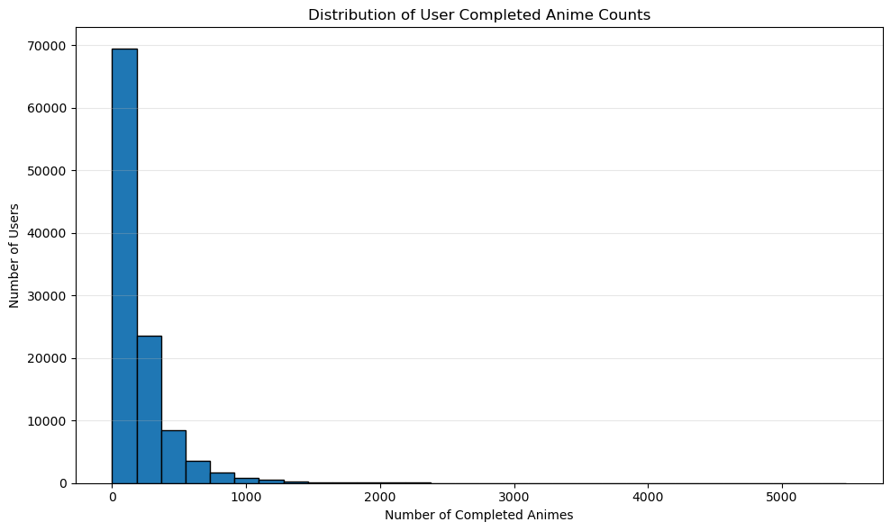

```python
user_completed_list = cleaned_users_df.select("user_completed").rdd.flatMap(lambda x: [x[0]]).collect()

plt.figure(figsize=(10, 6))
plt.hist(user_completed_list, bins=30, edgecolor='black')
plt.xlabel("Number of Completed Animes")
plt.ylabel("Number of Users")
plt.title("Distribution of User Completed Anime Counts")
plt.grid(axis='y', alpha=0.3)
plt.tight_layout()
plt.show()
```

```python
cleaned_users_df.filter(col("user_completed") > 2000).toPandas()
```

|  | user_id | username | user_completed | gender | birth_date |
| --- | --- | --- | --- | --- | --- |
| 0 | 2485327 | MistButterfly | 3923 | Female | 1992-01-16 00:00:00 |
| 1 | 48442 | soccerscot15 | 2189 | Male | 1992-05-14 00:00:00 |
| 2 | 294198 | Pullman | 4137 | Male | 1989-10-22 00:00:00 |
| 3 | 1599841 | Balskra | 2065 | Male | 1994-06-15 00:00:00 |
| 4 | 4846696 | -Ackerman | 2176 | Male | 1998-07-16 00:00:00 |
| ... | ... | ... | ... | ... | ... |
| 174 | 3585761 | Willshire | 2105 | Male | 1998-04-06 00:00:00 |
| 175 | 3386677 | Hyuse | 2659 | Male | 1994-12-25 00:00:00 |
| 176 | 3429907 | Xenovia | 2033 | Male | 1997-10-13 00:00:00 |
| 177 | 1406739 | DarkBlade16 | 2520 | Male | 1992-11-28 00:00:00 |
| 178 | 3570779 | SakataYusuke | 4567 | Male | 1997-03-08 00:00:00 |

179 rows × 5 columns

```python
# list users with completed animes less than 10
cleaned_users_df.filter(col("user_completed") < 5).toPandas()
```

|  | user_id | username | user_completed | gender | birth_date |
| --- | --- | --- | --- | --- | --- |
| 0 | 326733 | Skallington | 3 | Male | 1991-03-15 00:00:00 |
| 1 | 5927342 | Elysiun | 4 | Male | 1984-11-16 00:00:00 |
| 2 | 47167 | jimothy000 | 0 | Male | 1995-04-25 00:00:00 |
| 3 | 14658 | L-LawlietDN | 0 | Male | 1995-05-29 00:00:00 |
| 4 | 48172 | Saito23 | 4 | Male | 1988-12-26 00:00:00 |
| ... | ... | ... | ... | ... | ... |
| 3837 | 2284241 | LHenderson | 3 | Male | 1995-08-04 00:00:00 |
| 3838 | 242922 | myan11 | 1 | Female | 1993-04-01 00:00:00 |
| 3839 | 90521 | ivan80 | 0 | Male | 1981-06-05 00:00:00 |
| 3840 | 188615 | Darkcrusader | 3 | Male | 1986-02-27 00:00:00 |
| 3841 | 193449 | crystinutza | 0 | Female | 1995-12-30 00:00:00 |

3842 rows × 5 columns

Lets remove the users who have watched less than 5 animes. Not trusting their votes 😈

```python
# remove users from cleaned_users_df with completed animes less than 5
cleaned_users_df = cleaned_users_df.filter(col("user_completed") >= 5)

cleaned_users_df.show()
print("cleaned_users_df count:", cleaned_users_df.count())
```

```
+-------+---------------+--------------+------+-------------------+
|user_id|       username|user_completed|gender|         birth_date|
+-------+---------------+--------------+------+-------------------+
|2255153|       karthiga|            49|Female|1990-04-29 00:00:00|
|  37326|      Damonashu|           195|  Male|1991-08-01 00:00:00|
| 228342|          bskai|           414|  Male|1990-12-14 00:00:00|
| 327311| terune_uzumaki|             5|Female|1998-08-24 00:00:00|
|5015094|          Bas_G|           114|  Male|1999-10-24 00:00:00|
|3129315|       HimeAria|            87|Female|1996-09-26 00:00:00|
|  61677|         Slimak|           224|  Male|1988-02-21 00:00:00|
|2485327|  MistButterfly|          3923|Female|1992-01-16 00:00:00|
| 253613|  ProperBritish|           233|  Male|1992-02-20 00:00:00|
| 144049|        kioniel|           433|  Male|1988-01-16 00:00:00|
|      1|          Xinil|           230|  Male|1985-03-04 00:00:00|
|2529849|       helenply|           184|Female|1999-08-30 00:00:00|
|4538087|       hood_rad|           314|  Male|1997-10-31 00:00:00|
|   5309|detestedlove311|            29|Female|1989-09-14 00:00:00|
|  18867|    ihasabucket|           146|  Male|1984-09-08 00:00:00|
| 340873|    xTheFallenx|           655|  Male|1993-05-29 00:00:00|
|6951406|      zZKinhoZz|            65|  Male|2000-04-04 00:00:00|
| 502599|    glittermilk|            35|Female|1994-04-13 00:00:00|
|2637159|      Lithuelle|           148|Female|1985-10-19 00:00:00|
|  19539|     scootarski|           269|  Male|1984-10-12 00:00:00|
+-------+---------------+--------------+------+-------------------+
only showing top 20 rows
cleaned_users_df count: 104868
```

Since we cleaned up users. Lets keep only the users we have in the users_animes

```python
# Get distinct usernames from cleaned_users_df
distinct_usernames_from_users = cleaned_users_df.select("username").distinct()

# join cleaned_users_animes_df with distinct user names to keep only rows where username exists in cleaned_users_df
filtered_cleaned_users_animes_df = cleaned_users_animes_df.join(
    distinct_usernames_from_users,
    on="username",
    how="inner"
)

print("filtered_cleaned_users_animes_df count:", filtered_cleaned_users_animes_df.count())
filtered_cleaned_users_animes_df.show()
```

```
filtered_cleaned_users_animes_df count: 23976584
+--------+--------+--------+
|username|anime_id|my_score|
+--------+--------+--------+
|karthiga|      59|       7|
|karthiga|      74|       7|
|karthiga|     120|       7|
|karthiga|     178|       7|
|karthiga|     210|       7|
|karthiga|     232|       6|
|karthiga|     233|       6|
|karthiga|     249|       8|
|karthiga|     269|      10|
|karthiga|     721|       7|
|karthiga|     853|       7|
|karthiga|     857|      10|
|karthiga|     957|       8|
|karthiga|    1557|       8|
|karthiga|    1571|       8|
|karthiga|    1579|       9|
|karthiga|    1698|       7|
|karthiga|    1735|       9|
|karthiga|    1914|       7|
|karthiga|    1974|       8|
+--------+--------+--------+
only showing top 20 rows
```

Update cleaned_users_animes_df with the filtered ones

```python
cleaned_users_animes_df = filtered_cleaned_users_animes_df
```

## Data status after clean up

We did some clean ups on data sets. Lets take a look at the current status.

```python
# cleaned_animes_df
cleaned_animes_df.show()

print("cleaned_animes_df count:", cleaned_animes_df.count())
```

```
+--------+--------------------+--------+--------------------+-----+---------+------+----------+-------+---------+--------------------+
|anime_id|               title|episodes|              rating|score|scored_by|  rank|popularity|members|favorites|              studio|
+--------+--------------------+--------+--------------------+-----+---------+------+----------+-------+---------+--------------------+
|   11013|       Inu x Boku SS|      12|PG-13 - Teens 13 ...| 7.63|   139250|1274.0|       231| 283882|     2809|    David Production|
|    2104|    Seto no Hanayome|      26|PG-13 - Teens 13 ...| 7.89|    91206| 727.0|       366| 204003|     2579|               Gonzo|
|    5262|  Shugo Chara!! Doki|      51|       PG - Children| 7.55|    37129|1508.0|      1173|  70127|      802|           Satelight|
|     721|       Princess Tutu|      38|PG-13 - Teens 13 ...| 8.21|    36501| 307.0|       916|  93312|     3344|      Hal Film Maker|
|   12365| Bakuman. 3rd Season|      25|PG-13 - Teens 13 ...| 8.67|   107767|  50.0|       426| 182765|     2082|           J.C.Staff|
|    6586| Yume-iro Pâtissière|      50|        G - All Ages| 8.03|    21618| 526.0|      1630|  45625|      826|Studio Pierrot, S...|
|     178|        Ultra Maniac|      26|        G - All Ages| 7.26|     9663|2594.0|      2490|  22778|      122|     Production Reed|
|    2787|Shakugan no Shana...|      24|PG-13 - Teens 13 ...| 7.72|   126085|1066.0|       332| 220591|     1075|           J.C.Staff|
|    4477|Nodame Cantabile:...|      11|PG-13 - Teens 13 ...| 8.24|    53908| 281.0|       988|  85660|      282|           J.C.Staff|
|     853|Ouran Koukou Host...|      26|PG-13 - Teens 13 ...| 8.34|   335137| 205.0|        69| 538843|    24072|               Bones|
|    4814|  Junjou Romantica 2|      12|PG-13 - Teens 13 ...| 8.15|    66565| 374.0|       799| 108186|     1123|         Studio Deen|
|    7054|Kaichou wa Maid-s...|      26|PG-13 - Teens 13 ...|  8.2|   315130| 314.0|        71| 531292|    14436|           J.C.Staff|
|   11123|Sekaiichi Hatsukoi 2|      12|PG-13 - Teens 13 ...| 8.23|    53285| 288.0|       945|  89543|      726|         Studio Deen|
|   14227|Tonari no Kaibuts...|      13|PG-13 - Teens 13 ...| 7.71|   281448|1093.0|        88| 482105|     4064|   Brain&#039;s Base|
|     269|              Bleach|     366|PG-13 - Teens 13 ...|  7.9|   433097| 693.0|        18| 819284|    40718|      Studio Pierrot|
|      59|             Chobits|      26|PG-13 - Teens 13 ...| 7.53|   175388|1546.0|       188| 317641|     3271|            Madhouse|
|    6045|      Kimi ni Todoke|      25|PG-13 - Teens 13 ...| 8.13|   212710| 400.0|       111| 417136|     8041|      Production I.G|
|    1735|  Naruto: Shippuuden|     500|PG-13 - Teens 13 ...| 8.18|   385179| 337.0|        20| 794112|    42846|      Studio Pierrot|
|     210|             Ranma ½|     161|    R+ - Mild Nudity| 7.85|    59911| 802.0|       623| 134537|     2742|         Studio Deen|
|    4224|           Toradora!|      25|PG-13 - Teens 13 ...| 8.39|   557898| 174.0|        13| 910373|    35322|           J.C.Staff|
+--------+--------------------+--------+--------------------+-----+---------+------+----------+-------+---------+--------------------+
only showing top 20 rows
cleaned_animes_df count: 2687
```

```python
# cleaned_users_df
cleaned_users_df.show()

print("cleaned_users_df count:", cleaned_users_df.count())
```

```
+-------+---------------+--------------+------+-------------------+
|user_id|       username|user_completed|gender|         birth_date|
+-------+---------------+--------------+------+-------------------+
|2255153|       karthiga|            49|Female|1990-04-29 00:00:00|
|  37326|      Damonashu|           195|  Male|1991-08-01 00:00:00|
| 228342|          bskai|           414|  Male|1990-12-14 00:00:00|
| 327311| terune_uzumaki|             5|Female|1998-08-24 00:00:00|
|5015094|          Bas_G|           114|  Male|1999-10-24 00:00:00|
|3129315|       HimeAria|            87|Female|1996-09-26 00:00:00|
|  61677|         Slimak|           224|  Male|1988-02-21 00:00:00|
|2485327|  MistButterfly|          3923|Female|1992-01-16 00:00:00|
| 253613|  ProperBritish|           233|  Male|1992-02-20 00:00:00|
| 144049|        kioniel|           433|  Male|1988-01-16 00:00:00|
|      1|          Xinil|           230|  Male|1985-03-04 00:00:00|
|2529849|       helenply|           184|Female|1999-08-30 00:00:00|
|4538087|       hood_rad|           314|  Male|1997-10-31 00:00:00|
|   5309|detestedlove311|            29|Female|1989-09-14 00:00:00|
|  18867|    ihasabucket|           146|  Male|1984-09-08 00:00:00|
| 340873|    xTheFallenx|           655|  Male|1993-05-29 00:00:00|
|6951406|      zZKinhoZz|            65|  Male|2000-04-04 00:00:00|
| 502599|    glittermilk|            35|Female|1994-04-13 00:00:00|
|2637159|      Lithuelle|           148|Female|1985-10-19 00:00:00|
|  19539|     scootarski|           269|  Male|1984-10-12 00:00:00|
+-------+---------------+--------------+------+-------------------+
only showing top 20 rows
cleaned_users_df count: 104868
```

```python
# cleaned_users_animes_df
cleaned_users_animes_df.show()

print("cleaned_users_animes_df count:", cleaned_users_animes_df.count())
```

```
+--------+--------+--------+
|username|anime_id|my_score|
+--------+--------+--------+
|karthiga|      59|       7|
|karthiga|      74|       7|
|karthiga|     120|       7|
|karthiga|     178|       7|
|karthiga|     210|       7|
|karthiga|     232|       6|
|karthiga|     233|       6|
|karthiga|     249|       8|
|karthiga|     269|      10|
|karthiga|     721|       7|
|karthiga|     853|       7|
|karthiga|     857|      10|
|karthiga|     957|       8|
|karthiga|    1557|       8|
|karthiga|    1571|       8|
|karthiga|    1579|       9|
|karthiga|    1698|       7|
|karthiga|    1735|       9|
|karthiga|    1914|       7|
|karthiga|    1974|       8|
+--------+--------+--------+
only showing top 20 rows
```

```
[Stage 131:=======>                                                 (1 + 7) / 8]
```

```
cleaned_users_animes_df count: 23976584
```

### Distribution of scores (ratings)

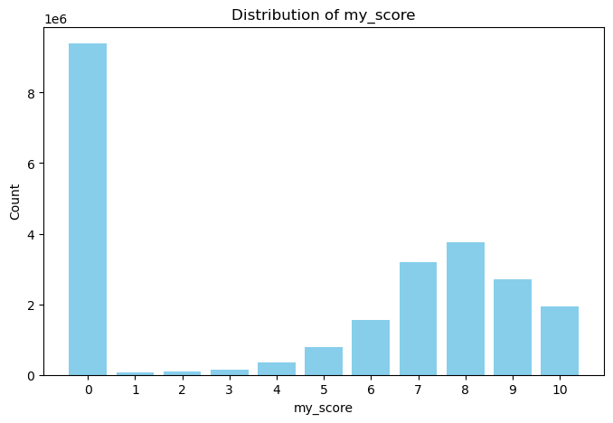

```python
my_score_dist = cleaned_users_animes_df.groupBy("my_score").count().orderBy("my_score")
my_score_pd = my_score_dist.toPandas()

plt.figure(figsize=(8, 5))
plt.bar(my_score_pd["my_score"], my_score_pd["count"], color='skyblue')
plt.xlabel("my_score")
plt.ylabel("Count")
plt.title("Distribution of my_score")
plt.xticks(my_score_pd["my_score"])
plt.show()
```

Our goal is to give recommendations of poplar animes. But we have some animes scored as lower than 5, around 9 million (1e6 = 1 million). In other words, there are about 9 million rows that has score value as less than 5. Lets analyze.

```python
# animes are scored with less than 5 ordered with anime_id
anime_ids_scored_less_5 = cleaned_users_animes_df.filter(col("my_score") < 5).select("anime_id").distinct().orderBy("anime_id")
anime_ids_scored_less_5.show()
```

```
[Stage 154:=================================================>       (7 + 1) / 8]
```

```
+--------+
|anime_id|
+--------+
|       1|
|       6|
|       7|
|       8|
|      15|
|      16|
|      17|
|      18|
|      19|
|      20|
|      22|
|      24|
|      25|
|      26|
|      27|
|      28|
|      29|
|      30|
|      33|
|      44|
+--------+
only showing top 20 rows
```

```python
from pyspark.sql import functions as F

# Display the anime with id 1 from cleaned_animes_df
anime_id_1 = cleaned_animes_df.filter(col("anime_id") == 1).select("anime_id", "title", "episodes", "rating", "score", "scored_by")
anime_id_1.show(truncate=False)
```

```
+--------+------------+--------+------------------------------+-----+---------+
|anime_id|title       |episodes|rating                        |score|scored_by|
+--------+------------+--------+------------------------------+-----+---------+
|1       |Cowboy Bebop|26      |R - 17+ (violence & profanity)|8.81 |365465   |
+--------+------------+--------+------------------------------+-----+---------+
```

anime_id == 1 is probably the most popular anime in the world which is Cowboy Bebop 🔫. But seems like there are some people scored it with 0

```python
cleaned_users_animes_df.filter((col("my_score") < 5) & (col("anime_id") == 1)).show()
```

```
+--------------+--------+--------+
|      username|anime_id|my_score|
+--------------+--------+--------+
|       kioniel|       1|       2|
|     Lithuelle|       1|       0|
|       Sakurei|       1|       0|
|   LyannaStark|       1|       0|
|ShinyShinigami|       1|       0|
|      Seishuku|       1|       0|
|      Mukkashi|       1|       0|
|       namiSWN|       1|       0|
|      bails649|       1|       0|
|    Skitungen2|       1|       0|
|    clannad187|       1|       0|
|  Awesomemikko|       1|       0|
|        Leyzou|       1|       0|
|       ellowel|       1|       0|
|        lila94|       1|       0|
|    shadowrost|       1|       0|
|        Cleaye|       1|       0|
|  ButterflyBoi|       1|       0|
| AnimeFan71194|       1|       0|
|       tykmerc|       1|       0|
+--------------+--------+--------+
only showing top 20 rows
```

There are people who scored Cowboy Bebop with those scores. Such a cruel world.

```python
cleaned_animes_df.filter(col("anime_id").isin([row.anime_id for row in anime_ids_scored_less_5.collect()])).orderBy("anime_id").show()
```

```
+--------+--------------------+--------+--------------------+-----+---------+------+----------+-------+---------+--------------------+
|anime_id|               title|episodes|              rating|score|scored_by|  rank|popularity|members|favorites|              studio|
+--------+--------------------+--------+--------------------+-----+---------+------+----------+-------+---------+--------------------+
|       1|        Cowboy Bebop|      26|R - 17+ (violence...| 8.81|   365465|  27.0|        38| 707773|    39145|             Sunrise|
|       6|              Trigun|      26|PG-13 - Teens 13 ...| 8.31|   197843| 234.0|       138| 373877|     9795|            Madhouse|
|       7|  Witch Hunter Robin|      26|PG-13 - Teens 13 ...| 7.34|    31908|2292.0|      1104|  75017|      524|             Sunrise|
|       8|Beet the Vandel B...|      52|       PG - Children| 7.04|     4760|3400.0|      3495|  11276|       13|      Toei Animation|
|      15|        Eyeshield 21|     145|PG-13 - Teens 13 ...| 8.05|    48825| 487.0|       812| 106718|     1650|       Studio Gallop|
|      16|Hachimitsu to Clover|      24|PG-13 - Teens 13 ...| 8.14|    54404| 382.0|       500| 160519|     3618|           J.C.Staff|
|      17|Hungry Heart: Wil...|      52|PG-13 - Teens 13 ...| 7.69|     8885|1130.0|      2967|  16161|      204|    Nippon Animation|
|      18|Initial D Fourth ...|      24|PG-13 - Teens 13 ...| 8.24|    37675| 276.0|      1261|  64574|      588|            A.C.G.T.|
|      19|             Monster|      74|    R+ - Mild Nudity| 8.69|   118856|  49.0|       152| 353310|    17399|            Madhouse|
|      20|              Naruto|     220|PG-13 - Teens 13 ...| 7.88|   648605| 745.0|        10| 980265|    34468|      Studio Pierrot|
|      22| Tennis no Ouji-sama|     178|PG-13 - Teens 13 ...| 8.01|    48149| 550.0|       806| 107492|     2833|          Trans Arts|
|      24|       School Rumble|      26|PG-13 - Teens 13 ...| 8.02|   101593| 537.0|       347| 214621|     4522|        Studio Comet|
|      25|           Sunabouzu|      24|R - 17+ (violence...| 7.52|    34377|1586.0|      1008|  83603|      638|               Gonzo|
|      26|          Texhnolyze|      22|    R+ - Mild Nudity| 7.78|    29726| 932.0|       661| 126584|     2597|            Madhouse|
|      27|       Trinity Blood|      24|R - 17+ (violence...| 7.41|    59596|1998.0|       638| 131899|     1378|               Gonzo|
|      28|    Yakitate!! Japan|      69|PG-13 - Teens 13 ...| 8.02|    26532| 540.0|      1301|  62326|      748|             Sunrise|
|      29|              Zipang|      26|PG-13 - Teens 13 ...| 7.54|     4155|1546.0|      3432|  11799|      108|         Studio Deen|
|      30|Neon Genesis Evan...|      26|PG-13 - Teens 13 ...| 8.32|   364012| 223.0|        48| 641101|    41098|Gainax, Tatsunoko...|
|      33|Kenpuu Denki Berserk|      25|    R+ - Mild Nudity| 8.45|   153890| 132.0|       210| 302027|    12562|                 OLM|
|      44|Rurouni Kenshin: ...|       4|R - 17+ (violence...| 8.79|    89117|  31.0|       481| 167218|     4683|         Studio Deen|
+--------+--------------------+--------+--------------------+-----+---------+------+----------+-------+---------+--------------------+
only showing top 20 rows
```

Ok. There are people that voted the animes above with a score less than 5. And the ones above are top tier ones. So to be consistent, lets remove the rows (user scores for animes) in cleaned_users_animes where the scores are less than 5.

```python
# lets clean up the cleaned_users_animes_df where my_score is less than 5
cleaned_users_animes_df = cleaned_users_animes_df.filter(col("my_score") >= 5)

# show and print count
cleaned_users_animes_df.show()
print("cleaned_users_animes_df count:", cleaned_users_animes_df.count())
```

```
+--------+--------+--------+
|username|anime_id|my_score|
+--------+--------+--------+
|karthiga|      59|       7|
|karthiga|      74|       7|
|karthiga|     120|       7|
|karthiga|     178|       7|
|karthiga|     210|       7|
|karthiga|     232|       6|
|karthiga|     233|       6|
|karthiga|     249|       8|
|karthiga|     269|      10|
|karthiga|     721|       7|
|karthiga|     853|       7|
|karthiga|     857|      10|
|karthiga|     957|       8|
|karthiga|    1557|       8|
|karthiga|    1571|       8|
|karthiga|    1579|       9|
|karthiga|    1698|       7|
|karthiga|    1735|       9|
|karthiga|    1914|       7|
|karthiga|    1974|       8|
+--------+--------+--------+
only showing top 20 rows
```

```
[Stage 193:>                                                        (0 + 8) / 8]
```

```
cleaned_users_animes_df count: 13929072
```

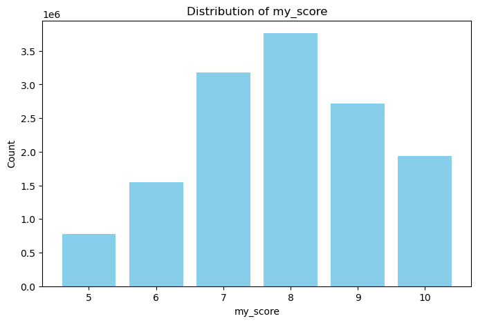

```python
my_score_dist = cleaned_users_animes_df.groupBy("my_score").count().orderBy("my_score")
my_score_pd = my_score_dist.toPandas()

plt.figure(figsize=(8, 5))
plt.bar(my_score_pd["my_score"], my_score_pd["count"], color='skyblue')
plt.xlabel("my_score")
plt.ylabel("Count")
plt.title("Distribution of my_score")
plt.xticks(my_score_pd["my_score"])
plt.show()
```

Now we have more nicer score distrubition.

```python
cleaned_users_animes_df.printSchema()
```

```
root
 |-- username: string (nullable = true)
 |-- anime_id: long (nullable = true)
 |-- my_score: long (nullable = true)
```

## Prepare Data for ALS

We did clean ups but lets be sure we dont have null cells in rows. Otherwise ALS can fail.

```python
# Filter out any null values in the cleaned_users_animes_df
ratings_df = cleaned_users_animes_df.filter(
    col("username").isNotNull() &
    col("anime_id").isNotNull() &
    col("my_score").isNotNull()
)
```

```python
from pyspark.ml.feature import StringIndexer

# Convert username (string) to userId (numeric)
# ALS requires numeric IDs for both users and items
# Save the indexer model to use later for converting back to usernames
indexer = StringIndexer(inputCol="username", outputCol="userId", handleInvalid="skip")
username_indexer_model = indexer.fit(ratings_df)
ratings_df = username_indexer_model.transform(ratings_df)
```

```python
ratings_df = ratings_df.select(
    col("username"),
    col("userId").cast("int"),
    col("anime_id").cast("int").alias("itemId"),
    col("my_score").cast("float").alias("rating")
)
```

```python
ratings_df.show()
ratings_df.count()
```

```
+--------+------+------+------+
|username|userId|itemId|rating|
+--------+------+------+------+
|karthiga| 69607|    59|   7.0|
|karthiga| 69607|    74|   7.0|
|karthiga| 69607|   120|   7.0|
|karthiga| 69607|   178|   7.0|
|karthiga| 69607|   210|   7.0|
|karthiga| 69607|   232|   6.0|
|karthiga| 69607|   233|   6.0|
|karthiga| 69607|   249|   8.0|
|karthiga| 69607|   269|  10.0|
|karthiga| 69607|   721|   7.0|
|karthiga| 69607|   853|   7.0|
|karthiga| 69607|   857|  10.0|
|karthiga| 69607|   957|   8.0|
|karthiga| 69607|  1557|   8.0|
|karthiga| 69607|  1571|   8.0|
|karthiga| 69607|  1579|   9.0|
|karthiga| 69607|  1698|   7.0|
|karthiga| 69607|  1735|   9.0|
|karthiga| 69607|  1914|   7.0|
|karthiga| 69607|  1974|   8.0|
+--------+------+------+------+
only showing top 20 rows
```

```
13929072
```

```python
# Create a mapping from userId back to username for later use
username_mapping = ratings_df.select("username", "userId").distinct().orderBy("userId")
username_mapping.show()
```

```
[Stage 244:==============>                                          (2 + 6) / 8]
```

```
+---------------+------+
|       username|userId|
+---------------+------+
|_thiagobrisolla|     0|
|    Shouichirou|     1|
|       rpgothic|     2|
|    CaptainZoro|     3|
|         Garyus|     4|
|        Kairoku|     5|
|        MikeOne|     6|
|         edinaa|     7|
|          Kayro|     8|
|     nikolai131|     9|
|     BerryChanx|    10|
|   DeadlyKizuna|    11|
| shadow_wolf_92|    12|
|     ShanaFlame|    13|
|      d3v4st4t3|    14|
|         jaioni|    15|
|        Kyon974|    16|
|        redbull|    17|
|          Sitha|    18|
|     Zetsushige|    19|
+---------------+------+
only showing top 20 rows
```

Lets check our ratings dataset is skewed or not. Spark will partition that while it is processing them. So we can take a look at the count of each partition and see it is skewed or not.

```python
ratings_df.withColumn("partition", F.spark_partition_id()).groupBy("partition").count().orderBy("partition").show()
```

```
[Stage 253:=======>                                                 (1 + 7) / 8]
```

```
+---------+-------+
|partition|  count|
+---------+-------+
|        0|1799892|
|        1|1841553|
|        2|1808036|
|        3|1858488|
|        4|1884929|
|        5|1850513|
|        6|1941250|
|        7| 944411|
+---------+-------+
```

Seems like we are good.

### Split Data to Training and Test

```python
train_data, test_data = ratings_df.randomSplit([0.7, 0.3], seed=GLOBAL_SEED)

print(f"Training data size: {train_data.count()} ratings")
print(f"Test data size: {test_data.count()} ratings")
```

```
Training data size: 9749653 ratings
```

```
[Stage 271:=======>                                                 (1 + 7) / 8]
```

```
Test data size: 4179419 ratings
```

Save test_data to a directory, so we can run tests after models trained.

```python
# Convert to pandas DataFrame
test_data_pd = test_data.toPandas()

# Save as a single parquet file using pandas
test_data_pd.to_parquet("../data/test_data_single.parquet", index=False)
```

# Training ALS

We will cache the training data and test data to run a bit faster.

```python
train_data.cache()
test_data.cache()

train_data.printSchema()
test_data.printSchema()
```

```
root
 |-- username: string (nullable = true)
 |-- userId: integer (nullable = true)
 |-- itemId: integer (nullable = true)
 |-- rating: float (nullable = true)

root
 |-- username: string (nullable = true)
 |-- userId: integer (nullable = true)
 |-- itemId: integer (nullable = true)
 |-- rating: float (nullable = true)
```

The training process will take time. So lets save the best model so far in a directory in case we face with an issue.

```python
import os
import shutil

# Define the directory for saving the best model
MODEL_SAVE_DIR = "trained_models"
BEST_MODEL_PATH = os.path.join(MODEL_SAVE_DIR, "best_model")

if not os.path.exists(MODEL_SAVE_DIR):
    os.makedirs(MODEL_SAVE_DIR)
    print(f"Created directory: {MODEL_SAVE_DIR}")
else:
    print(f"Directory '{MODEL_SAVE_DIR}' already exists.")


def save_model(model):
    # before saving, check if the directory already exists and remove it
    if os.path.exists(BEST_MODEL_PATH):
        shutil.rmtree(BEST_MODEL_PATH)
        print(f"Removed existing model at {BEST_MODEL_PATH}")

    # Save the best model so far
    try:
        model.write().save(BEST_MODEL_PATH)
        print(f"Model saved to {BEST_MODEL_PATH}")
    except Exception as e:
        print(f"Error saving model: {e}")
```

```
Created directory: trained_models
```

```python
from pyspark.ml.evaluation import RegressionEvaluator
from pyspark.ml.recommendation import ALS
import time


# We'll try different combinations of based on requirements:
# - rank: number of latent (secret) factors (hidden features) in the model
# - iterations: how many times to optimize the model
# - lambda: regularization parameter to prevent overfitting

ranks = [10, 50, 200]
iterations = [10, 50, 200]
lambdas = [0.01, 0.1]


# will save the results of each model
results = []
best_model = None

# create a RegressionEvaluator to evaluate the model performance
evaluator_rmse = RegressionEvaluator(metricName="rmse", labelCol="rating", predictionCol="prediction")
evaluator_mse = RegressionEvaluator(metricName="mse", labelCol="rating", predictionCol="prediction")

print("Starting ALS hyperparameter tuning loop...")
print(f"Will train {len(ranks) * len(iterations) * len(lambdas)} models...")


# Loop through all parameter combinations (18 total models)
for rank in ranks:
    for num_iterations in iterations:
        for reg_param in lambdas:
            # Create the ALS model with current parameters
            # Parameters explained:
            # - maxIter: maximum iterations for optimization
            # - rank: number of latent factors (model complexity)
            # - regParam: regularization parameter (prevents overfitting)
            # - coldStartStrategy="drop": ignore users/items with no training data
            # - nonnegative=True: ensures predictions are non-negative
            als = ALS(
                maxIter=num_iterations,
                rank=rank,
                regParam=reg_param,
                userCol="userId",
                itemCol="itemId",
                ratingCol="rating",
                coldStartStrategy="drop",
                nonnegative=True,
            )

            print(f"Training model with: rank={rank}, iterations={num_iterations}, lambda={reg_param}")

            start_time = time.time()

            model = als.fit(train_data)

            end_time = time.time()
            training_time = end_time - start_time

            print(f"Model trained in {training_time:.2f} seconds")

            print("Making predictions on test data...")
            predictions = model.transform(test_data)
            print("Predictions made.")

            # Note: `coldStartStrategy="drop"` handles users/items in test set but not in training.
            # However, predictions can still be NaN if the model couldn't generate one for a valid pair.
            # RegressionEvaluator will error out on NaNs, so we must drop them.
            predictions_clean = predictions.na.drop(subset=["prediction"])

            # Evaluate the model
            rmse = evaluator_rmse.evaluate(predictions_clean)
            mse = evaluator_mse.evaluate(predictions_clean)

            print(f"RMSE = {rmse:.4f} (lower is better)")
            print(f"MSE = {mse:.4f} (lower is better)")

            # Check if this model is the best so far
            # if best_model is None then set it to the current model (for first iteration)
            if best_model is None:
                best_model = model
                save_model(best_model)
            else:
                # get the previous best RMSE from results
                prev_best_rmse = min([result["rmse"] for result in results]) if results else float("inf")
                # if current rmse is lower than the previous best RMSE, then this is the new best model
                if rmse < prev_best_rmse:
                    best_model = model
                    save_model(best_model)
                    print("Found a new best model!")

            # Store the results for this iteration
            results.append(
                {
                    "rank": rank,
                    "iterations": num_iterations,
                    "lambda": reg_param,
                    "rmse": rmse,
                    "mse": mse,
                    "training_time": training_time,
                }
            )

            print("-" * 50)

print("\nHyperparameter tuning finished.")
```

```
Starting ALS hyperparameter tuning loop...
Will train 18 models...
Training model with: rank=10, iterations=10, lambda=0.01
```

```
Model trained in 18.47 seconds
Making predictions on test data...
Predictions made.
```

```
RMSE = 1.0531 (lower is better)
MSE = 1.1091 (lower is better)
```

```
Model saved to trained_models/best_model
--------------------------------------------------
Training model with: rank=10, iterations=10, lambda=0.1
```

```
Model trained in 12.00 seconds
Making predictions on test data...
Predictions made.
```

```
RMSE = 1.0780 (lower is better)
MSE = 1.1621 (lower is better)
--------------------------------------------------
Training model with: rank=10, iterations=50, lambda=0.01
```

```
Model trained in 46.55 seconds
Making predictions on test data...
Predictions made.
```

```
RMSE = 1.0365 (lower is better)
MSE = 1.0743 (lower is better)
Removed existing model at trained_models/best_model
Model saved to trained_models/best_model
Found a new best model!
--------------------------------------------------
Training model with: rank=10, iterations=50, lambda=0.1
```

```
Model trained in 46.45 seconds
Making predictions on test data...
Predictions made.
```

```
RMSE = 1.0279 (lower is better)
MSE = 1.0566 (lower is better)
Removed existing model at trained_models/best_model
Model saved to trained_models/best_model
Found a new best model!
--------------------------------------------------
Training model with: rank=10, iterations=200, lambda=0.01
```

```
Model trained in 201.95 seconds
Making predictions on test data...
Predictions made.
```

```
RMSE = 1.0349 (lower is better)
MSE = 1.0709 (lower is better)
--------------------------------------------------
Training model with: rank=10, iterations=200, lambda=0.1
```

```
Model trained in 192.64 seconds
Making predictions on test data...
Predictions made.
```

```
RMSE = 1.0261 (lower is better)
MSE = 1.0529 (lower is better)
Removed existing model at trained_models/best_model
```

```
Model saved to trained_models/best_model
Found a new best model!
--------------------------------------------------
Training model with: rank=50, iterations=10, lambda=0.01
```

```
Model trained in 69.50 seconds
Making predictions on test data...
Predictions made.
```

```
RMSE = 1.1268 (lower is better)
MSE = 1.2696 (lower is better)
--------------------------------------------------
Training model with: rank=50, iterations=10, lambda=0.1
```

```
Model trained in 60.37 seconds
Making predictions on test data...
Predictions made.
```

```
RMSE = 1.0677 (lower is better)
MSE = 1.1399 (lower is better)
--------------------------------------------------
Training model with: rank=50, iterations=50, lambda=0.01
```

```
Model trained in 297.38 seconds
Making predictions on test data...
Predictions made.
```

```
RMSE = 1.1347 (lower is better)
MSE = 1.2876 (lower is better)
--------------------------------------------------
Training model with: rank=50, iterations=50, lambda=0.1
```

```
Model trained in 249.60 seconds
Making predictions on test data...
Predictions made.
```

```
RMSE = 1.0179 (lower is better)
MSE = 1.0362 (lower is better)
Removed existing model at trained_models/best_model
```

```
Model saved to trained_models/best_model
Found a new best model!
--------------------------------------------------
Training model with: rank=50, iterations=200, lambda=0.01
```

```
Model trained in 1197.16 seconds
Making predictions on test data...
Predictions made.
```

```
RMSE = 1.1252 (lower is better)
MSE = 1.2661 (lower is better)
--------------------------------------------------
Training model with: rank=50, iterations=200, lambda=0.1
```

```
Model trained in 992.65 seconds
Making predictions on test data...
Predictions made.
```

```
RMSE = 1.0160 (lower is better)
MSE = 1.0323 (lower is better)
Removed existing model at trained_models/best_model
```

```
Model saved to trained_models/best_model
Found a new best model!
--------------------------------------------------
Training model with: rank=200, iterations=10, lambda=0.01
```

```
Model trained in 1158.43 seconds
Making predictions on test data...
Predictions made.
```

```
RMSE = 1.1490 (lower is better)
MSE = 1.3202 (lower is better)
--------------------------------------------------
Training model with: rank=200, iterations=10, lambda=0.1
```

```
Model trained in 623.10 seconds
Making predictions on test data...
Predictions made.
```

```
RMSE = 1.0591 (lower is better)
MSE = 1.1216 (lower is better)
--------------------------------------------------
Training model with: rank=200, iterations=50, lambda=0.01
```

```
Model trained in 5315.55 seconds
Making predictions on test data...
Predictions made.
```

```
RMSE = 1.1424 (lower is better)
MSE = 1.3052 (lower is better)
--------------------------------------------------
Training model with: rank=200, iterations=50, lambda=0.1
```

```
Model trained in 3085.32 seconds
Making predictions on test data...
Predictions made.
```

```
RMSE = 1.0171 (lower is better)
MSE = 1.0345 (lower is better)
--------------------------------------------------
Training model with: rank=200, iterations=200, lambda=0.01
```

```
Model trained in 17534.51 seconds
Making predictions on test data...
Predictions made.
```

```
RMSE = 1.1386 (lower is better)
MSE = 1.2965 (lower is better)
--------------------------------------------------
Training model with: rank=200, iterations=200, lambda=0.1
```

```
Model trained in 12004.17 seconds
Making predictions on test data...
Predictions made.
```

```
RMSE = 1.0153 (lower is better)
MSE = 1.0309 (lower is better)
Removed existing model at trained_models/best_model
```

```
Model saved to trained_models/best_model
Found a new best model!
--------------------------------------------------

Hyperparameter tuning finished.
```

#### Save results

```python
import pandas as pd

results_df = pd.DataFrame(results)


# Save results to JSON file so we can use it later
results_df.reset_index(drop=True).to_json('results_df.json', orient='records')
```

# Analyze Model Results

```python
import pandas as pd

results_df = pd.read_json('results_df.json', orient='records')

results_df
```

|  | rank | iterations | lambda | rmse | mse | training_time |
| --- | --- | --- | --- | --- | --- | --- |
| 0 | 10 | 10 | 0.01 | 1.053138 | 1.109099 | 18.467362 |
| 1 | 10 | 10 | 0.10 | 1.078030 | 1.162148 | 12.003281 |
| 2 | 10 | 50 | 0.01 | 1.036493 | 1.074317 | 46.545613 |
| 3 | 10 | 50 | 0.10 | 1.027901 | 1.056581 | 46.446398 |
| 4 | 10 | 200 | 0.01 | 1.034855 | 1.070924 | 201.954750 |
| 5 | 10 | 200 | 0.10 | 1.026130 | 1.052942 | 192.640619 |
| 6 | 50 | 10 | 0.01 | 1.126756 | 1.269580 | 69.499915 |
| 7 | 50 | 10 | 0.10 | 1.067670 | 1.139919 | 60.369922 |
| 8 | 50 | 50 | 0.01 | 1.134708 | 1.287561 | 297.384154 |
| 9 | 50 | 50 | 0.10 | 1.017938 | 1.036197 | 249.597830 |
| 10 | 50 | 200 | 0.01 | 1.125199 | 1.266073 | 1197.158064 |
| 11 | 50 | 200 | 0.10 | 1.016012 | 1.032281 | 992.649239 |
| 12 | 200 | 10 | 0.01 | 1.148996 | 1.320191 | 1158.427301 |
| 13 | 200 | 10 | 0.10 | 1.059064 | 1.121616 | 623.099152 |
| 14 | 200 | 50 | 0.01 | 1.142440 | 1.305169 | 5315.547476 |
| 15 | 200 | 50 | 0.10 | 1.017095 | 1.034482 | 3085.323199 |
| 16 | 200 | 200 | 0.01 | 1.138623 | 1.296463 | 17534.509740 |
| 17 | 200 | 200 | 0.10 | 1.015348 | 1.030931 | 12004.173558 |

**The longest single model (rank=200, iterations=200, lambda=0.01) took 4.9 hours alone!**

### Model Performance Evaluation

We trained 18 ALS models with different combinations of rank (10, 50, 200), iterations (10, 50, 200), and lambda (0.01, 0.1). For each model, we calculated the Mean Squared Error (MSE) and Root Mean Squared Error (RMSE) on the test set.

**Explanation of Metrics**

- MSE (Mean Squared Error): This is the average of the squares of the errors (the difference between actual and predicted ratings). Squaring the errors penalizes larger errors more heavily. A lower MSE indicates a better fit to the data.
- RMSE (Root Mean Squared Error): This is the square root of the MSE. It brings the metric back to the original unit of the rating scale, making it more interpretable. For example, if your ratings are on a 1-10 scale, an RMSE of 1.5 means that, on average, the model's predictions are off by about 1.5 rating points. A lower RMSE indicates better model performance.

```python
# create a new column for training time in minutes with 2 decimal places
results_df["training_time_mins"] = (results_df["training_time"] / 60.0).round(2)
```

```python
print("Hyperparameter Tuning Results (RMSE and MSE):")
# sort results by RMSE and show top 5
results_df_sorted = results_df.sort_values(by="rmse").reset_index(drop=True)
print(results_df_sorted[["rank", "iterations", "lambda", "rmse", "mse", "training_time_mins"]].head(5))

# first results_df_sorted is the best model
best_model_params_row = results_df_sorted.iloc[0]


print("\n--- Best Model ---")
print("Parameters yielding the lowest RMSE:")
print(f"Rank:     {best_model_params_row['rank']}")
print(f"MaxIter:  {best_model_params_row['iterations']}")
print(f"RegParam: {best_model_params_row['lambda']}")
print(f"Lowest RMSE: {best_model_params_row['rmse']:.4f}")
print(f"MSE for best model: {best_model_params_row['mse']:.4f}")
print(f"Training time: {best_model_params_row['training_time_mins']} minutes")
```

```
Hyperparameter Tuning Results (RMSE and MSE):
   rank  iterations  lambda      rmse       mse  training_time_mins
0   200         200     0.1  1.015348  1.030931              200.07
1    50         200     0.1  1.016012  1.032281               16.54
2   200          50     0.1  1.017095  1.034482               51.42
3    50          50     0.1  1.017938  1.036197                4.16
4    10         200     0.1  1.026130  1.052942                3.21

--- Best Model ---
Parameters yielding the lowest RMSE:
Rank:     200.0
MaxIter:  200.0
RegParam: 0.1
Lowest RMSE: 1.0153
MSE for best model: 1.0309
Training time: 200.07 minutes
```

### Best Model

Best RMSE: 1.0153 Best MSE: 1.0309 Parameters: rank=200, iterations=200, lambda=0.10 This means, on average, the model's predictions are off by about 1.02 rating points, which is quite reasonable for a 1-10 rating scale.

**Why is this the best model?**

The best model has the lowest RMSE and MSE among all tested configurations. Increasing both the rank and iterations allows the model to better capture the latent structure in the data, while a higher lambda (0.10) helps prevent overfitting.

**RMSE Trends**

## Plots for different parameter combinations

### RMSE - MSE with paramaters labeled

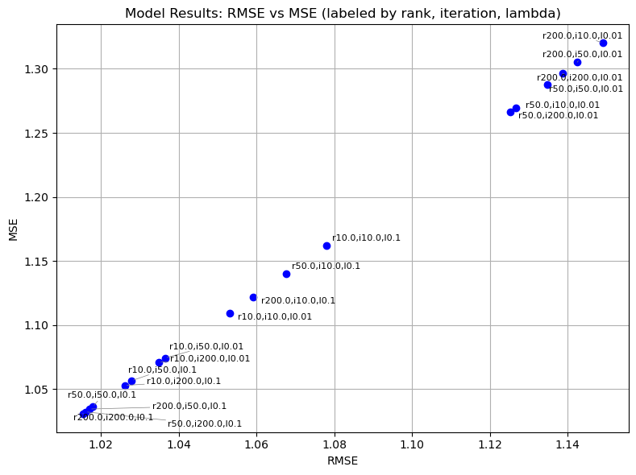

```python
from adjustText import adjust_text

plt.figure(figsize=(8, 6))
plt.scatter(results_df["rmse"], results_df["mse"], color="blue")

texts = []
for idx, row in results_df.iterrows():
    label = f"r{row['rank']},i{row['iterations']},l{row['lambda']}"
    texts.append(plt.text(row["rmse"], row["mse"], label, fontsize=8))

adjust_text(texts, arrowprops=dict(arrowstyle="-", color="gray", lw=0.5))

plt.xlabel("RMSE")
plt.ylabel("MSE")
plt.title("Model Results: RMSE vs MSE (labeled by rank, iteration, lambda)")
plt.grid(True)
plt.tight_layout()
plt.show()
```

### RMSE vs Iterations (for each rank)

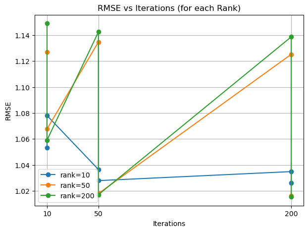

```python
plt.figure(figsize=(7, 5))

for rank in sorted(results_df["rank"].unique()):
    subset = results_df[results_df["rank"] == rank]
    plt.plot(subset["iterations"], subset["rmse"], marker="o", label=f"rank={rank}")

plt.xlabel("Iterations")
plt.ylabel("RMSE")
plt.title("RMSE vs Iterations (for each Rank)")
plt.legend()
plt.grid(True)
plt.xticks(subset["iterations"].unique())
plt.show()
```

### RMSE vs Rank (for each iteration)

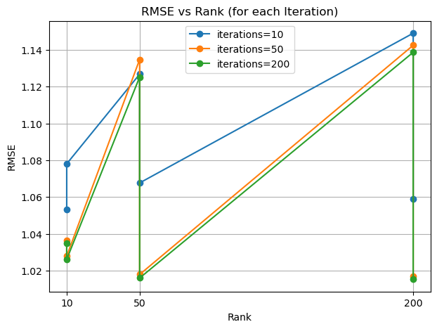

```python
plt.figure(figsize=(7, 5))
for iteration in sorted(results_df["iterations"].unique()):
    subset = results_df[results_df["iterations"] == iteration]
    plt.plot(subset["rank"], subset["rmse"], marker="o", label=f"iterations={iteration}")
plt.xlabel("Rank")
plt.ylabel("RMSE")
plt.title("RMSE vs Rank (for each Iteration)")
plt.legend()
plt.grid(True)
plt.xticks(subset["rank"].unique())
plt.show()
```

### RMSE vs Lambda (for each rank and iteration)

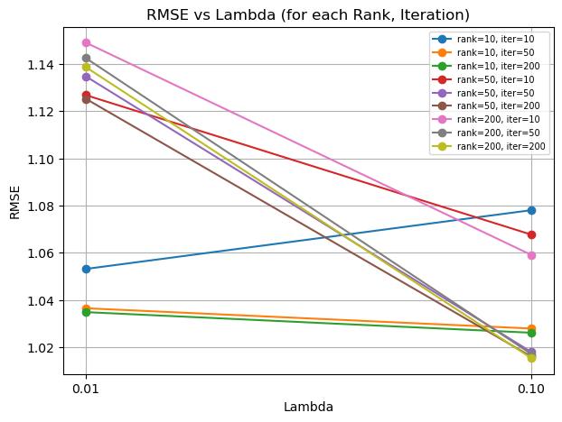

```python
plt.figure(figsize=(7, 5))
for (rank, iteration), group in results_df.groupby(["rank", "iterations"]):
    plt.plot(group["lambda"], group["rmse"], marker="o", label=f"rank={rank}, iter={iteration}")
plt.xlabel("Lambda")
plt.ylabel("RMSE")
plt.title("RMSE vs Lambda (for each Rank, Iteration)")
plt.legend(fontsize=7)
plt.grid(True)
plt.xticks(group["lambda"].unique())
plt.show()
```

# Predictions with Best Model

Load saved best model from directory

```python
# Define the directory for saving the best model
MODEL_SAVE_DIR = "trained_models"
BEST_MODEL_PATH = os.path.join(MODEL_SAVE_DIR, "best_model")
```

```python
from pyspark.ml.recommendation import ALSModel

loaded_best_model = ALSModel.load(BEST_MODEL_PATH)
print(f"Successfully loaded the best model from {BEST_MODEL_PATH}")
```

```
Successfully loaded the best model from trained_models/best_model
```

Lets make predictions with test data first and compare with actual ratings.

```python
# load test_data_single.parquet from data directory
test_data_single_path = "../data/test_data_single.parquet"
test_data = spark.read.parquet(test_data_single_path)
```

```python
predictions = loaded_best_model.transform(test_data)
```

```python
# add predictions to cache for faster access
predictions.cache()
```

```
DataFrame[username: string, userId: int, itemId: int, rating: float, prediction: float]
```

```python
sample_df = predictions.select("userId", "itemId", "rating", "prediction").limit(25).toPandas()
```

```python
sample_df = sample_df.merge(username_mapping.toPandas(), on="userId", how="left")
anime_titles = cleaned_animes_df.select("anime_id", "title").toPandas()
sample_df = sample_df.merge(anime_titles, left_on="itemId", right_on="anime_id", how="left")

# Round predictions to one decimal point
sample_df["prediction"] = sample_df["prediction"].round(1)

# Show side by side comparison
display(sample_df[["username", "title", "rating", "prediction"]])
```

|  | username | title | rating | prediction |
| --- | --- | --- | --- | --- |
| 0 | Kawaielli | Cowboy Bebop | 8.0 | 8.3 |
| 1 | Kawaielli | Monster | 8.0 | 8.4 |
| 2 | Kawaielli | Trinity Blood | 7.0 | 7.1 |
| 3 | Kawaielli | Kenpuu Denki Berserk | 7.0 | 8.0 |
| 4 | Kawaielli | Aa! Megami-sama! (TV) | 5.0 | 7.1 |
| 5 | Kawaielli | Kidou Tenshi Angelic Layer | 7.0 | 7.1 |
| 6 | Kawaielli | Ai Yori Aoshi | 8.0 | 6.9 |
| 7 | Kawaielli | D.C.: Da Capo | 5.0 | 6.6 |
| 8 | Kawaielli | Last Exile | 8.0 | 7.7 |
| 9 | Kawaielli | Fullmetal Alchemist | 8.0 | 8.0 |
| 10 | Kawaielli | Gate Keepers 21 | 7.0 | 6.8 |
| 11 | Kawaielli | Hikaru no Go | 8.0 | 7.9 |
| 12 | Kawaielli | Jinki:Extend | 6.0 | 6.4 |
| 13 | Kawaielli | Kannazuki no Miko | 7.0 | 6.9 |
| 14 | Kawaielli | Kimi ga Nozomu Eien | 7.0 | 7.3 |
| 15 | Kawaielli | RahXephon | 7.0 | 7.4 |
| 16 | Kawaielli | Shingetsutan Tsukihime | 5.0 | 7.1 |
| 17 | Kawaielli | Rizelmine | 7.0 | 6.7 |
| 18 | Kawaielli | Speed Grapher | 8.0 | 7.5 |
| 19 | Kawaielli | Video Girl Ai | 7.0 | 7.2 |
| 20 | Kawaielli | Yumeria | 6.0 | 6.2 |
| 21 | Kawaielli | Elfen Lied | 6.0 | 7.6 |
| 22 | Kawaielli | Eureka Seven | 8.0 | 7.8 |
| 23 | Kawaielli | Genshiken | 7.0 | 7.7 |
| 24 | Kawaielli | Great Teacher Onizuka | 8.0 | 8.3 |

### Compare Distribution of Real vs Predicted Ratings

```python
# Get predictions and actual ratings as numpy arrays
actual_ratings = predictions.select("rating").toPandas()["rating"].values
predicted_ratings = predictions.select("prediction").toPandas()["prediction"].values
```

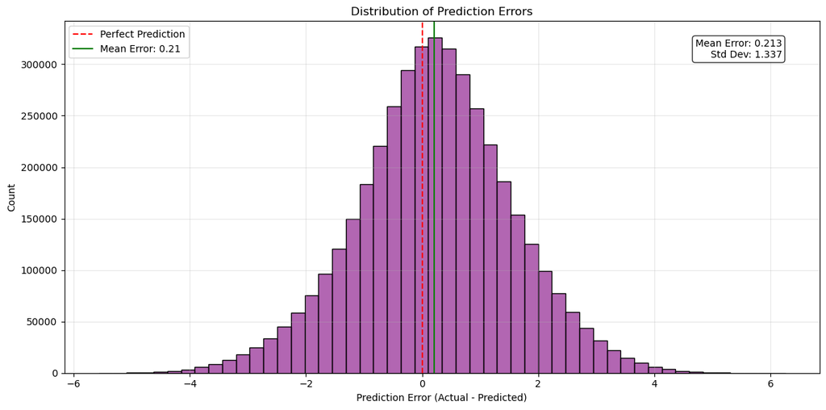

```python
import seaborn as sns
import numpy as np

# Calculate prediction errors (residuals)
errors = actual_ratings - predicted_ratings

# Create figure for error distribution
plt.figure(figsize=(12, 6))

# Create histogram of errors
sns.histplot(data=errors, bins=50, color="purple", alpha=0.6)

# Add vertical line at x=0 (perfect prediction)
plt.axvline(x=0, color="red", linestyle="--", label="Perfect Prediction")

# Calculate mean and std of errors
mean_error = np.mean(errors)
std_error = np.std(errors)

# Add vertical line for mean error
plt.axvline(x=mean_error, color="green", linestyle="-", label=f"Mean Error: {mean_error:.2f}")

# Add labels and title
plt.xlabel("Prediction Error (Actual - Predicted)")
plt.ylabel("Count")
plt.title("Distribution of Prediction Errors")

# Add text box with statistics
stats_text = f"Mean Error: {mean_error:.3f}\nStd Dev: {std_error:.3f}"
plt.text(
    0.95,
    0.95,
    stats_text,
    transform=plt.gca().transAxes,
    verticalalignment="top",
    horizontalalignment="right",
    bbox=dict(boxstyle="round", facecolor="white", alpha=0.8),
)

plt.legend()
plt.grid(True, alpha=0.3)
plt.tight_layout()
plt.show()
```

**X-axis: Prediction Error (Actual - Predicted)**

This represents the difference between the actual ratings users gave to animes and what our best model predicted Negative values mean the model over-predicted (predicted higher than actual) Positive values mean the model under-predicted (predicted lower than actual) Zero would be a perfect prediction

**Y-axis: Count**

Shows how many predictions fall into each error range The height of each bar indicates the frequency of that particular error magnitude

**Key observations from the chart**

- Distribution Shape: The histogram shows a normal (bell-curve) distribution centered very close to zero, which is excellent news for our model's performance.
- Mean Error: 0.213 (shown in green line)

This means our model has a very slight tendency to under-predict ratings by about 0.2 points on average This is remarkably close to zero, indicating minimal systematic bias

- Standard Deviation: 1.337

Shows the spread of errors around the mean Most predictions fall within about ±2.67 rating points (2 standard deviations)

- Concentration Around Zero: The majority of predictions cluster around the red dashed line (perfect prediction), indicating our model is quite accurate for most cases.

**In other words:**

The tight distribution around zero shows our ALS model with parameters (rank=200, iterations=200, lambda=0.10) is performing very well. The small mean error (0.213) indicates no significant systematic bias. Most errors fall within a reasonable range for a 5-10 rating scale.

### Top N Recommendations for a Specific User

```python
ratings_df.show()
```

```
+--------+------+------+------+
|username|userId|itemId|rating|
+--------+------+------+------+
|karthiga| 69607|    59|   7.0|
|karthiga| 69607|    74|   7.0|
|karthiga| 69607|   120|   7.0|
|karthiga| 69607|   178|   7.0|
|karthiga| 69607|   210|   7.0|
|karthiga| 69607|   232|   6.0|
|karthiga| 69607|   233|   6.0|
|karthiga| 69607|   249|   8.0|
|karthiga| 69607|   269|  10.0|
|karthiga| 69607|   721|   7.0|
|karthiga| 69607|   853|   7.0|
|karthiga| 69607|   857|  10.0|
|karthiga| 69607|   957|   8.0|
|karthiga| 69607|  1557|   8.0|
|karthiga| 69607|  1571|   8.0|
|karthiga| 69607|  1579|   9.0|
|karthiga| 69607|  1698|   7.0|
|karthiga| 69607|  1735|   9.0|
|karthiga| 69607|  1914|   7.0|
|karthiga| 69607|  1974|   8.0|
+--------+------+------+------+
only showing top 20 rows
```

```python
user_vote_counts = ratings_df.groupBy("username") \
    .count() \
    .orderBy("count", ascending=False)

# Take a random sample of 1% from the top voters
user_vote_counts = user_vote_counts.sample(fraction=0.01, seed=42).toPandas()

user_vote_counts
```

|  | username | count |
| --- | --- | --- |
| 0 | Black-Flash | 971 |
| 1 | Dignity | 935 |
| 2 | Yangsu | 885 |
| 3 | leea | 776 |
| 4 | Ojou_san | 684 |
| ... | ... | ... |
| 1073 | pestenamanoh | 1 |
| 1074 | kirokatana | 1 |
| 1075 | Sirmrbond | 1 |
| 1076 | Mirokette | 1 |
| 1077 | joudsenseii | 1 |

1078 rows × 2 columns

```python
# Lets see MishaMisha from cleaned_users_df
MishaMisha = cleaned_users_animes_df.filter(col("username") == "MishaMisha").sort("my_score", ascending=False).toPandas()

# lets show the anime titles as well
MishaMisha = MishaMisha.merge(cleaned_animes_df.select("anime_id", "title").toPandas(), on="anime_id", how="left")

MishaMisha
```

|  | username | anime_id | my_score | title |
| --- | --- | --- | --- | --- |
| 0 | MishaMisha | 59 | 10 | Chobits |
| 1 | MishaMisha | 853 | 10 | Ouran Koukou Host Club |
| 2 | MishaMisha | 4224 | 10 | Toradora! |
| 3 | MishaMisha | 849 | 10 | Suzumiya Haruhi no Yuuutsu |
| 4 | MishaMisha | 1887 | 10 | Lucky☆Star |
| 5 | MishaMisha | 3457 | 10 | Vampire Knight |
| 6 | MishaMisha | 4752 | 10 | Vampire Knight: Guilty |
| 7 | MishaMisha | 177 | 10 | Tsubasa Chronicle |
| 8 | MishaMisha | 101 | 10 | Air |
| 9 | MishaMisha | 969 | 10 | Tsubasa Chronicle 2nd Season |
| 10 | MishaMisha | 2993 | 10 | Rosario to Vampire |
| 11 | MishaMisha | 4214 | 10 | Rosario to Vampire Capu2 |
| 12 | MishaMisha | 2685 | 10 | Tsubasa: Tokyo Revelations |
| 13 | MishaMisha | 1535 | 9 | Death Note |
| 14 | MishaMisha | 144 | 9 | Kanon |
| 15 | MishaMisha | 2167 | 8 | Clannad |
| 16 | MishaMisha | 861 | 7 | xxxHOLiC |
| 17 | MishaMisha | 469 | 7 | Karin |
| 18 | MishaMisha | 471 | 6 | To Heart 2 |
| 19 | MishaMisha | 3464 | 6 | Kemeko Deluxe! |
| 20 | MishaMisha | 346 | 6 | W: Wish |
| 21 | MishaMisha | 232 | 5 | Cardcaptor Sakura |
| 22 | MishaMisha | 24 | 5 | School Rumble |
| 23 | MishaMisha | 934 | 5 | Higurashi no Naku Koro ni |
| 24 | MishaMisha | 2923 | 5 | Shugo Chara! |

```python
# get user_id for MishaMisha from username id mapping
misha_user = username_mapping.filter(col("username") == "MishaMisha").toPandas()
print(misha_user)
```

```
[Stage 339:=======>                                                 (1 + 7) / 8]
```

```
     username  userId
0  MishaMisha   85229
```

#### Recommendations for specific user

```python
from pyspark.sql import Row
from pyspark.sql.functions import explode

misha_user_id = int(misha_user["userId"].values[0])


misha_df = spark.createDataFrame([Row(userId=misha_user_id)])

# Get top 25 recommendations for this user
user_recs = loaded_best_model.recommendForUserSubset(misha_df, 25)

# Explode the recommendations array to rows
recs_exploded = user_recs.select("userId", explode("recommendations").alias("rec"))
recs_flat = recs_exploded.select(
    "userId", recs_exploded.rec.itemId.alias("anime_id"), recs_exploded.rec.rating.alias("predicted_rating")
)

# Join with anime titles for readability
recs_with_titles = recs_flat.join(cleaned_animes_df.select("anime_id", "title"), on="anime_id", how="left").toPandas()
recs_with_titles
```

|  | anime_id | userId | predicted_rating | title |
| --- | --- | --- | --- | --- |
| 0 | 245 | 85229 | 9.384236 | Great Teacher Onizuka |
| 1 | 9969 | 85229 | 9.288939 | Gintama&#039; |
| 2 | 820 | 85229 | 9.270814 | Ginga Eiyuu Densetsu |
| 3 | 28977 | 85229 | 9.244169 | Gintama° |
| 4 | 9253 | 85229 | 9.228911 | Steins;Gate |
| 5 | 777 | 85229 | 9.226636 | Hellsing Ultimate |
| 6 | 2904 | 85229 | 9.221142 | Code Geass: Hangyaku no Lelouch R2 |
| 7 | 4181 | 85229 | 9.218471 | Clannad: After Story |
| 8 | 5114 | 85229 | 9.200512 | Fullmetal Alchemist: Brotherhood |
| 9 | 15417 | 85229 | 9.193359 | Gintama&#039;: Enchousen |
| 10 | 44 | 85229 | 9.191048 | Rurouni Kenshin: Meiji Kenkaku Romantan - Tsui... |
| 11 | 12029 | 85229 | 9.187375 | Uchuu Senkan Yamato 2199 |
| 12 | 1519 | 85229 | 9.133173 | Black Lagoon: The Second Barrage |
| 13 | 57 | 85229 | 9.126852 | Beck |
| 14 | 263 | 85229 | 9.099664 | Hajime no Ippo |
| 15 | 1575 | 85229 | 9.096842 | Code Geass: Hangyaku no Lelouch |
| 16 | 2001 | 85229 | 9.073700 | Tengen Toppa Gurren Lagann |
| 17 | 34096 | 85229 | 9.062193 | Gintama. |
| 18 | 1 | 85229 | 9.049817 | Cowboy Bebop |
| 19 | 889 | 85229 | 9.032007 | Black Lagoon |
| 20 | 5258 | 85229 | 9.008266 | Hajime no Ippo: New Challenger |
| 21 | 226 | 85229 | 9.007010 | Elfen Lied |
| 22 | 918 | 85229 | 9.003135 | Gintama |
| 23 | 36838 | 85229 | 9.001987 | Gintama.: Shirogane no Tamashii-hen |
| 24 | 45 | 85229 | 8.991434 | Rurouni Kenshin: Meiji Kenkaku Romantan |